# Introduction

LoanTap is a digital lending platform focused on delivering customized and flexible credit solutions to millennials, salaried professionals, and small businesses through innovative financial products. To scale lending responsibly, LoanTap’s data science team aims to strengthen its underwriting framework by leveraging data-driven risk assessment. This project focuses on analyzing borrower attributes and building a predictive model to evaluate creditworthiness for Personal Loans. Using exploratory data analysis, feature engineering, and logistic regression, the goal is to minimize defaults while maximizing profitable lending opportunities.

# Problem Statement

1. Analyze borrower demographic, financial, and credit behavior data to understand patterns influencing loan repayment and default risk.
2. Perform exploratory data analysis, preprocessing, feature engineering, and scaling to prepare clean and meaningful inputs for modeling.
3. Build and evaluate a Logistic Regression model to predict whether a borrower will fully repay or default on a Personal Loan using metrics such as ROC-AUC, Precision, Recall, and Classification Report.
4. Optimize the precision–recall tradeoff to reduce non-performing assets (NPAs) while ensuring genuine customers are not wrongly rejected.
5. Provide actionable business recommendations on credit approval strategy and repayment terms based on model insights.

# Importing Python Libraries

```python
import numpy as np
import pandas as pd
import matplotlib.pyplot as plt
import seaborn as sns
```

# Importing the Data

```python
df = pd.read_csv('/content/drive/MyDrive/01. Data Set for Colab Notebooks/LoanTap - Data.csv')
```

```python
df.head(3)
```

|  | loan_amnt | term | int_rate | installment | grade | sub_grade | emp_title | emp_length | home_ownership | annual_inc | ... | open_acc | pub_rec | revol_bal | revol_util | total_acc | initial_list_status | application_type | mort_acc | pub_rec_bankruptcies | address |
| --- | --- | --- | --- | --- | --- | --- | --- | --- | --- | --- | --- | --- | --- | --- | --- | --- | --- | --- | --- | --- | --- |
| 0 | 10000.0 | 36 months | 11.44 | 329.48 | B | B4 | Marketing | 10+ years | RENT | 117000.0 | ... | 16.0 | 0.0 | 36369.0 | 41.8 | 25.0 | w | INDIVIDUAL | 0.0 | 0.0 | 0174 Michelle Gateway\r\nMendozaberg, OK 22690 |
| 1 | 8000.0 | 36 months | 11.99 | 265.68 | B | B5 | Credit analyst | 4 years | MORTGAGE | 65000.0 | ... | 17.0 | 0.0 | 20131.0 | 53.3 | 27.0 | f | INDIVIDUAL | 3.0 | 0.0 | 1076 Carney Fort Apt. 347\r\nLoganmouth, SD 05113 |
| 2 | 15600.0 | 36 months | 10.49 | 506.97 | B | B3 | Statistician | < 1 year | RENT | 43057.0 | ... | 13.0 | 0.0 | 11987.0 | 92.2 | 26.0 | f | INDIVIDUAL | 0.0 | 0.0 | 87025 Mark Dale Apt. 269\r\nNew Sabrina, WV 05113 |

3 rows × 27 columns

# Basic Data Exploration

### 01. Identification of Variables and Data Types

```python
df.shape
```

```
(396030, 27)
```

1. Dataset has 396030 records
2. Dataset has 26 Features and 1 Target

```python
df.dtypes
```

|  | 0 |
| --- | --- |
| loan_amnt | float64 |
| term | object |
| int_rate | float64 |
| installment | float64 |
| grade | object |
| sub_grade | object |
| emp_title | object |
| emp_length | object |
| home_ownership | object |
| annual_inc | float64 |
| verification_status | object |
| issue_d | object |
| loan_status | object |
| purpose | object |
| title | object |
| dti | float64 |
| earliest_cr_line | object |
| open_acc | float64 |
| pub_rec | float64 |
| revol_bal | float64 |
| revol_util | float64 |
| total_acc | float64 |
| initial_list_status | object |
| application_type | object |
| mort_acc | float64 |
| pub_rec_bankruptcies | float64 |
| address | object |

**dtype:** object

```python
df.info()
```

```
<class 'pandas.core.frame.DataFrame'>
RangeIndex: 396030 entries, 0 to 396029
Data columns (total 27 columns):
 #   Column                Non-Null Count   Dtype
---  ------                --------------   -----
 0   loan_amnt             396030 non-null  float64
 1   term                  396030 non-null  object
 2   int_rate              396030 non-null  float64
 3   installment           396030 non-null  float64
 4   grade                 396030 non-null  object
 5   sub_grade             396030 non-null  object
 6   emp_title             373103 non-null  object
 7   emp_length            377729 non-null  object
 8   home_ownership        396030 non-null  object
 9   annual_inc            396030 non-null  float64
```

[output cut: 19 more lines]

### 02. Analysis of Basic Metrics

```python
df.describe(include='all')
```

|  | loan_amnt | term | int_rate | installment | grade | sub_grade | emp_title | emp_length | home_ownership | annual_inc | ... | open_acc | pub_rec | revol_bal | revol_util | total_acc | initial_list_status | application_type | mort_acc | pub_rec_bankruptcies | address |
| --- | --- | --- | --- | --- | --- | --- | --- | --- | --- | --- | --- | --- | --- | --- | --- | --- | --- | --- | --- | --- | --- |
| count | 396030.000000 | 396030 | 396030.000000 | 396030.000000 | 396030 | 396030 | 373103 | 377729 | 396030 | 3.960300e+05 | ... | 396030.000000 | 396030.000000 | 3.960300e+05 | 395754.000000 | 396030.000000 | 396030 | 396030 | 358235.000000 | 395495.000000 | 396030 |
| unique | NaN | 2 | NaN | NaN | 7 | 35 | 173105 | 11 | 6 | NaN | ... | NaN | NaN | NaN | NaN | NaN | 2 | 3 | NaN | NaN | 393700 |
| top | NaN | 36 months | NaN | NaN | B | B3 | Teacher | 10+ years | MORTGAGE | NaN | ... | NaN | NaN | NaN | NaN | NaN | f | INDIVIDUAL | NaN | NaN | USS Johnson\r\nFPO AE 48052 |
| freq | NaN | 302005 | NaN | NaN | 116018 | 26655 | 4389 | 126041 | 198348 | NaN | ... | NaN | NaN | NaN | NaN | NaN | 238066 | 395319 | NaN | NaN | 8 |
| mean | 14113.888089 | NaN | 13.639400 | 431.849698 | NaN | NaN | NaN | NaN | NaN | 7.420318e+04 | ... | 11.311153 | 0.178191 | 1.584454e+04 | 53.791749 | 25.414744 | NaN | NaN | 1.813991 | 0.121648 | NaN |
| std | 8357.441341 | NaN | 4.472157 | 250.727790 | NaN | NaN | NaN | NaN | NaN | 6.163762e+04 | ... | 5.137649 | 0.530671 | 2.059184e+04 | 24.452193 | 11.886991 | NaN | NaN | 2.147930 | 0.356174 | NaN |
| min | 500.000000 | NaN | 5.320000 | 16.080000 | NaN | NaN | NaN | NaN | NaN | 0.000000e+00 | ... | 0.000000 | 0.000000 | 0.000000e+00 | 0.000000 | 2.000000 | NaN | NaN | 0.000000 | 0.000000 | NaN |
| 25% | 8000.000000 | NaN | 10.490000 | 250.330000 | NaN | NaN | NaN | NaN | NaN | 4.500000e+04 | ... | 8.000000 | 0.000000 | 6.025000e+03 | 35.800000 | 17.000000 | NaN | NaN | 0.000000 | 0.000000 | NaN |
| 50% | 12000.000000 | NaN | 13.330000 | 375.430000 | NaN | NaN | NaN | NaN | NaN | 6.400000e+04 | ... | 10.000000 | 0.000000 | 1.118100e+04 | 54.800000 | 24.000000 | NaN | NaN | 1.000000 | 0.000000 | NaN |
| 75% | 20000.000000 | NaN | 16.490000 | 567.300000 | NaN | NaN | NaN | NaN | NaN | 9.000000e+04 | ... | 14.000000 | 0.000000 | 1.962000e+04 | 72.900000 | 32.000000 | NaN | NaN | 3.000000 | 0.000000 | NaN |
| max | 40000.000000 | NaN | 30.990000 | 1533.810000 | NaN | NaN | NaN | NaN | NaN | 8.706582e+06 | ... | 90.000000 | 86.000000 | 1.743266e+06 | 892.300000 | 151.000000 | NaN | NaN | 34.000000 | 8.000000 | NaN |

11 rows × 27 columns

```python
df.describe(include = np.number)
```

|  | loan_amnt | int_rate | installment | annual_inc | dti | open_acc | pub_rec | revol_bal | revol_util | total_acc | mort_acc | pub_rec_bankruptcies |
| --- | --- | --- | --- | --- | --- | --- | --- | --- | --- | --- | --- | --- |
| count | 396030.000000 | 396030.000000 | 396030.000000 | 3.960300e+05 | 396030.000000 | 396030.000000 | 396030.000000 | 3.960300e+05 | 395754.000000 | 396030.000000 | 358235.000000 | 395495.000000 |
| mean | 14113.888089 | 13.639400 | 431.849698 | 7.420318e+04 | 17.379514 | 11.311153 | 0.178191 | 1.584454e+04 | 53.791749 | 25.414744 | 1.813991 | 0.121648 |
| std | 8357.441341 | 4.472157 | 250.727790 | 6.163762e+04 | 18.019092 | 5.137649 | 0.530671 | 2.059184e+04 | 24.452193 | 11.886991 | 2.147930 | 0.356174 |
| min | 500.000000 | 5.320000 | 16.080000 | 0.000000e+00 | 0.000000 | 0.000000 | 0.000000 | 0.000000e+00 | 0.000000 | 2.000000 | 0.000000 | 0.000000 |
| 25% | 8000.000000 | 10.490000 | 250.330000 | 4.500000e+04 | 11.280000 | 8.000000 | 0.000000 | 6.025000e+03 | 35.800000 | 17.000000 | 0.000000 | 0.000000 |
| 50% | 12000.000000 | 13.330000 | 375.430000 | 6.400000e+04 | 16.910000 | 10.000000 | 0.000000 | 1.118100e+04 | 54.800000 | 24.000000 | 1.000000 | 0.000000 |
| 75% | 20000.000000 | 16.490000 | 567.300000 | 9.000000e+04 | 22.980000 | 14.000000 | 0.000000 | 1.962000e+04 | 72.900000 | 32.000000 | 3.000000 | 0.000000 |
| max | 40000.000000 | 30.990000 | 1533.810000 | 8.706582e+06 | 9999.000000 | 90.000000 | 86.000000 | 1.743266e+06 | 892.300000 | 151.000000 | 34.000000 | 8.000000 |

```python
df.describe(include = object)
```

|  | term | grade | sub_grade | emp_title | emp_length | home_ownership | verification_status | issue_d | loan_status | purpose | title | earliest_cr_line | initial_list_status | application_type | address |
| --- | --- | --- | --- | --- | --- | --- | --- | --- | --- | --- | --- | --- | --- | --- | --- |
| count | 396030 | 396030 | 396030 | 373103 | 377729 | 396030 | 396030 | 396030 | 396030 | 396030 | 394274 | 396030 | 396030 | 396030 | 396030 |
| unique | 2 | 7 | 35 | 173105 | 11 | 6 | 3 | 115 | 2 | 14 | 48816 | 684 | 2 | 3 | 393700 |
| top | 36 months | B | B3 | Teacher | 10+ years | MORTGAGE | Verified | Oct-2014 | Fully Paid | debt_consolidation | Debt consolidation | Oct-2000 | f | INDIVIDUAL | USS Johnson\r\nFPO AE 48052 |
| freq | 302005 | 116018 | 26655 | 4389 | 126041 | 198348 | 139563 | 14846 | 318357 | 234507 | 152472 | 3017 | 238066 | 395319 | 8 |

```python
unique_values = pd.DataFrame({'Type':df.dtypes,'Unique Values': df.nunique()})
unique_values.sort_values(by='Unique Values',ascending=False)
```

|  | Type | Unique Values |
| --- | --- | --- |
| address | object | 393700 |
| emp_title | object | 173105 |
| installment | float64 | 55706 |
| revol_bal | float64 | 55622 |
| title | object | 48816 |
| annual_inc | float64 | 27197 |
| dti | float64 | 4262 |
| loan_amnt | float64 | 1397 |
| revol_util | float64 | 1226 |
| earliest_cr_line | object | 684 |
| int_rate | float64 | 566 |
| total_acc | float64 | 118 |
| issue_d | object | 115 |
| open_acc | float64 | 61 |
| sub_grade | object | 35 |
| mort_acc | float64 | 33 |
| pub_rec | float64 | 20 |
| purpose | object | 14 |
| emp_length | object | 11 |
| pub_rec_bankruptcies | float64 | 9 |
| grade | object | 7 |
| home_ownership | object | 6 |
| verification_status | object | 3 |
| application_type | object | 3 |
| term | object | 2 |
| loan_status | object | 2 |
| initial_list_status | object | 2 |

```python
unique_values[unique_values['Type']=='object'].sort_values(by='Unique Values',ascending=False)
```

|  | Type | Unique Values |
| --- | --- | --- |
| address | object | 393700 |
| emp_title | object | 173105 |
| title | object | 48816 |
| earliest_cr_line | object | 684 |
| issue_d | object | 115 |
| sub_grade | object | 35 |
| purpose | object | 14 |
| emp_length | object | 11 |
| grade | object | 7 |
| home_ownership | object | 6 |
| verification_status | object | 3 |
| application_type | object | 3 |
| term | object | 2 |
| loan_status | object | 2 |
| initial_list_status | object | 2 |

### 03. Columns to be converted to Categorical Data (from Object)

```python
unique_values[(unique_values['Type']=='object') & (unique_values['Unique Values'] < 36)].sort_values(by='Unique Values',ascending=False)
```

|  | Type | Unique Values |
| --- | --- | --- |
| sub_grade | object | 35 |
| purpose | object | 14 |
| emp_length | object | 11 |
| grade | object | 7 |
| home_ownership | object | 6 |
| verification_status | object | 3 |
| application_type | object | 3 |
| term | object | 2 |
| loan_status | object | 2 |
| initial_list_status | object | 2 |

### 04. Identifying Missing Values

```python
missing_value = pd.DataFrame({'Type':df.dtypes,'Missing Value': df.isnull().sum(),'Percentage':(df.isnull().sum()/len(df))*100})
missing_value.sort_values(by='Percentage',ascending=False)
```

|  | Type | Missing Value | Percentage |
| --- | --- | --- | --- |
| mort_acc | float64 | 37795 | 9.543469 |
| emp_title | object | 22927 | 5.789208 |
| emp_length | object | 18301 | 4.621115 |
| title | object | 1756 | 0.443401 |
| pub_rec_bankruptcies | float64 | 535 | 0.135091 |
| revol_util | float64 | 276 | 0.069692 |
| installment | float64 | 0 | 0.000000 |
| int_rate | float64 | 0 | 0.000000 |
| term | object | 0 | 0.000000 |
| grade | object | 0 | 0.000000 |
| loan_amnt | float64 | 0 | 0.000000 |
| verification_status | object | 0 | 0.000000 |
| annual_inc | float64 | 0 | 0.000000 |
| home_ownership | object | 0 | 0.000000 |
| sub_grade | object | 0 | 0.000000 |
| dti | float64 | 0 | 0.000000 |
| issue_d | object | 0 | 0.000000 |
| loan_status | object | 0 | 0.000000 |
| purpose | object | 0 | 0.000000 |
| pub_rec | float64 | 0 | 0.000000 |
| open_acc | float64 | 0 | 0.000000 |
| earliest_cr_line | object | 0 | 0.000000 |
| revol_bal | float64 | 0 | 0.000000 |
| initial_list_status | object | 0 | 0.000000 |
| total_acc | float64 | 0 | 0.000000 |
| application_type | object | 0 | 0.000000 |
| address | object | 0 | 0.000000 |

### 05. Identifying Duplicates

```python
df.duplicated().sum()
```

```
np.int64(0)
```

1. Dataset has no duplicate record

### 06. Skewness Coefficient

```python
numerical_df = df.select_dtypes(include=['int64','float64'])
print("Skewness Coefficient")
print("-" * 20)
numerical_df.skew().round(4)
```

```
Skewness Coefficient
--------------------
```

|  | 0 |
| --- | --- |
| loan_amnt | 0.7773 |
| int_rate | 0.4207 |
| installment | 0.9836 |
| annual_inc | 41.0427 |
| dti | 431.0512 |
| open_acc | 1.2130 |
| pub_rec | 16.5766 |
| revol_bal | 11.7275 |
| revol_util | -0.0718 |
| total_acc | 0.8643 |
| mort_acc | 1.6001 |
| pub_rec_bankruptcies | 3.4234 |

**dtype:** float64

1. loan_amnt(0.77): Positively skewed, indicating more loans are on the lower end of the amount scale with a long tail towards higher amounts.
2. int_rate(0.42): Slightly positively skewed, suggesting a mild concentration of lower interest rates with a few high rates.
3. installment(0.98): Positively skewed, indicating most installment amounts are lower with a few higher values.
4. annual_inc(41.04): Highly positively skewed, indicating the majority of incomes are on the lower end with a few extremely high incomes.
5. dti(431.05): Extremely positively skewed, suggesting a heavy concentration of lower debt-to-income ratios with some extremely high values.
   - Note: Low DTI (Less Than 20%): This indicates that you have a healthy financial balance, with most of your income available for savings and discretionary spending. Moderate DTI (20-36%): A moderate DTI suggests that a significant portion of your income is allocated to debt payments but is still manageable.
6. open_acc(1.21): Positively skewed, indicating most borrowers have fewer open accounts with a long tail towards those with many open accounts.
   - Note:This could suggest a more conservative borrowing behavior where the majority of borrowers do not maintain numerous active credit lines.The financial institution’s customer base predominantly consists of borrowers who manage fewer credit accounts, potentially indicating lower credit utilization and possibly lower risk profiles.
7. pub_rec(16.57): Highly positively skewed, indicating the majority of borrowers have few public records with a long tail towards those with many public records.
8. revol_bal(11.72): Highly positively skewed, suggesting most revolving balances are lower with a few very high balances.
   - Note: Most borrowers have relatively low revolving credit balances. This implies that for the majority of customers, their outstanding balances on credit cards or revolving lines of credit are not very high. A large portion of the customer base manages their credit effectively, maintaining lower balances. This is generally a positive sign, indicating lower credit risk and potentially higher creditworthiness for these individuals.
9. revol_util(-0.07): Slightly negatively skewed, indicating a near-symmetrical distribution but with a slight tail towards lower utilization rates.
   - Note: Most customers manage their credit lines in a balanced way, which is generally a positive sign for credit risk assessment.
10. total_acc(0.86): Positively skewed, indicating most borrowers have fewer total accounts with a few having a very high number of accounts.
11. mort_acc(1.60): Positively skewed, indicating the majority of borrowers have few mortgage accounts with a long tail towards those with many accounts.
12. pub_rec_bankruptcies(3.42): Highly positively skewed, indicating most borrowers have no bankruptcies with a few having multiple bankruptcies.

### 07. Kurtosis Co-Efficient

```python
print("kurtosis co-efficient")
print("-" * 22)
numerical_df.kurt().round(4)
```

```
kurtosis co-efficient
----------------------
```

|  | 0 |
| --- | --- |
| loan_amnt | -0.0626 |
| int_rate | -0.1439 |
| installment | 0.7838 |
| annual_inc | 4238.5506 |
| dti | 237923.6765 |
| open_acc | 2.9669 |
| pub_rec | 1867.4666 |
| revol_bal | 384.2211 |
| revol_util | 2.7123 |
| total_acc | 1.2046 |
| mort_acc | 4.4772 |
| pub_rec_bankruptcies | 18.1042 |

**dtype:** float64

1. loan_amnt(-0.06): The distribution of loan amounts is close to normal, with slightly lighter tails indicating fewer extreme loan amounts compared to a normal distribution.
2. int_rate(-0.14): Interest rates are also near normally distributed, with a slight tendency towards lighter tails, suggesting fewer extremely high or low interest rates.
3. installment(0.78): Installment amounts have a distribution with moderately heavy tails, indicating some presence of outliers in the installment amounts.
4. annual_inc(4238.55): Annual income is highly leptokurtic, suggesting a significant presence of outliers with very high incomes, indicating extreme income values in the dataset.
5. dti(237923.67): Debt-to-income ratio shows an extremely high positive kurtosis, indicating the presence of extreme values or outliers in the debt-to-income ratio.
6. open_acc(2.96): The number of open accounts has moderately heavy tails, indicating some outliers with a high number of open accounts.
7. pub_rec(1867.46): Public records have a very high positive kurtosis, indicating a significant presence of extreme values or outliers.
8. revol_bal(384.22): Revolving balance is highly leptokurtic, suggesting many outliers with very high revolving balances.
9. revol_util(2.71): Revolving credit utilization has moderately heavy tails, indicating some presence of extreme utilization rates.
10. total_acc(1.20): Total number of accounts has moderately heavy tails, indicating some outliers with a very high total number of accounts.
11. mort_acc(4.47): Mortgage accounts have heavy tails, indicating some extreme values with very high numbers of mortgage accounts.
12. pub_rec_bankruptcies(18.10): Public record bankruptcies are highly leptokurtic, indicating a significant presence of extreme values or outliers

# Visual Analysis

### 01. Univariate Analysis (Object)

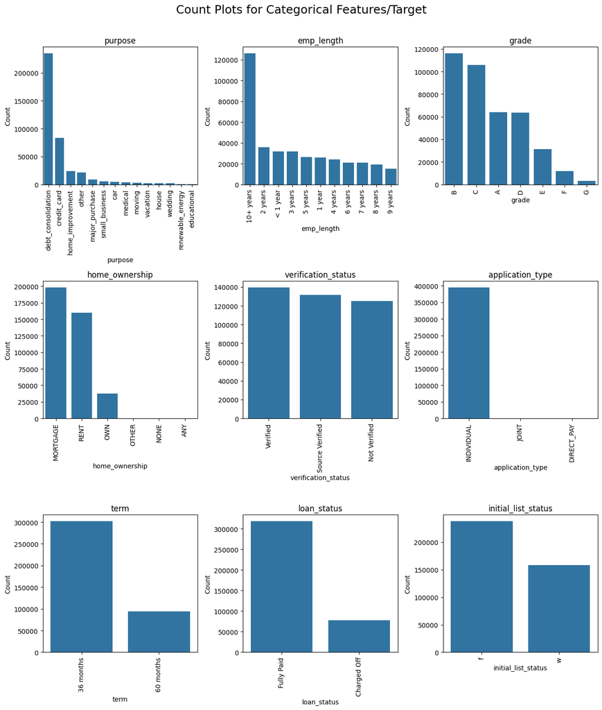

```python
obj_cols = unique_values[(unique_values['Type']=='object') & (unique_values['Unique Values'] < 35)].sort_values(by='Unique Values',ascending=False).index

n = (len(obj_cols) // 3) + (1 if len(obj_cols) % 3 > 0 else 0)

plt.figure(figsize=(13, 5 * n))

for j, col in enumerate(obj_cols,1):
    plt.subplot(n, 3, j)
    sns.countplot(data=df, x=col, order=df[col].value_counts().index)
    plt.xticks(rotation=90)
    plt.ylabel('Count')
    plt.xlabel(col)
    plt.title(col)

plt.suptitle("Count Plots for Categorical Features/Target", fontsize=18, y=1.01)
plt.tight_layout()
plt.show()
```

### 02. Univariate Analysis (Numerical)

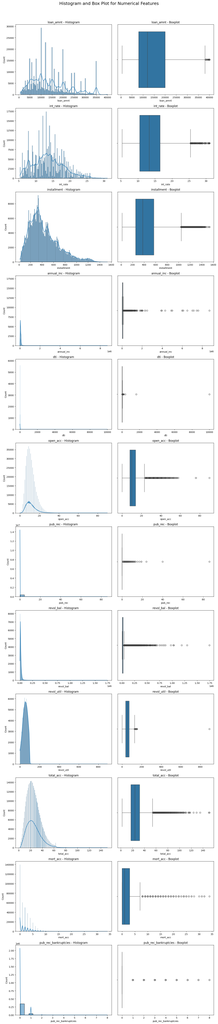

```python
num_cols = unique_values[unique_values['Type']=='float64'].index
n = len(num_cols)
plt.figure(figsize=(13,5*n))


j=1
for col in num_cols:
  plt.subplot(n,2,j)
  sns.histplot(df[col],kde= True)
  plt.xlabel(col)
  plt.title(f'{col} - Histogram')

  plt.subplot(n,2,j+1)
  sns.boxplot(x=df[col])
  plt.xlabel(col)
  plt.title(f'{col} - Boxplot')

  j+=2

plt.suptitle("Histogram and Box Plot for Numerical Features", fontsize=18,y = 1.01)
plt.tight_layout()
plt.show()
```

Data has outliers

### 03.Bivariate Analysis

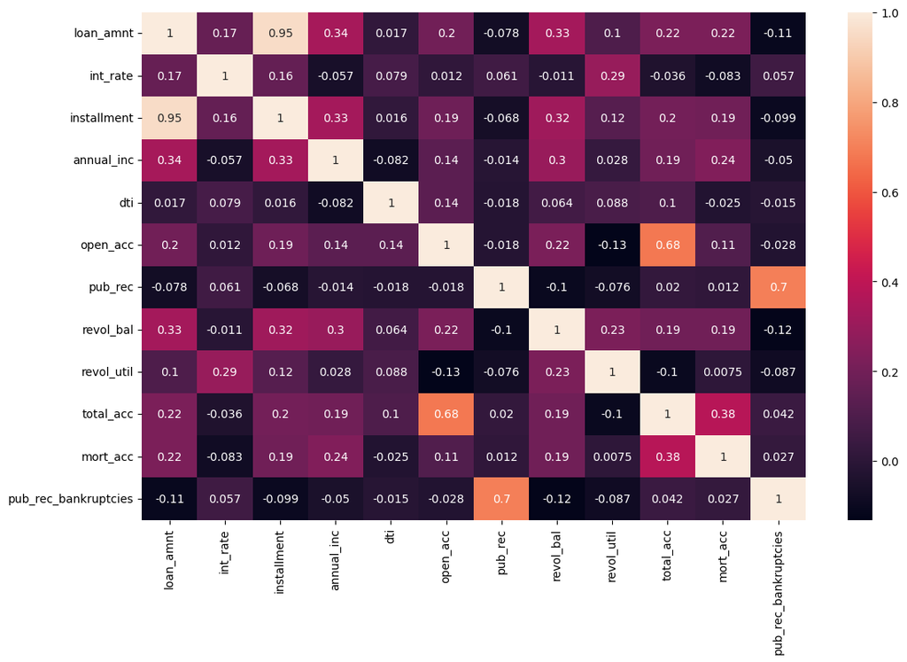

```python
plt.figure(figsize=(13, 8))
sns.heatmap(df.select_dtypes(include=['int64','float64']).corr(),annot=True)
```

We see Strong correlation between:

1. loan_amnt Vs installment (0.95)
2. pub_rec Vs pub_rec_bankruptcies (0.7)
3. open_acc Vs total_acc (0.68)

and Moderate correlation between:

1. total_acc Vs mort_acc (0.38)
2. loan_amnt Vs annual_inc (0.34)
3. loan_amnt Vs revol_bal (0.33)
4. installment Vs revol_bal (0.32)
5. annual_inc Vs revol_bal (0.3)

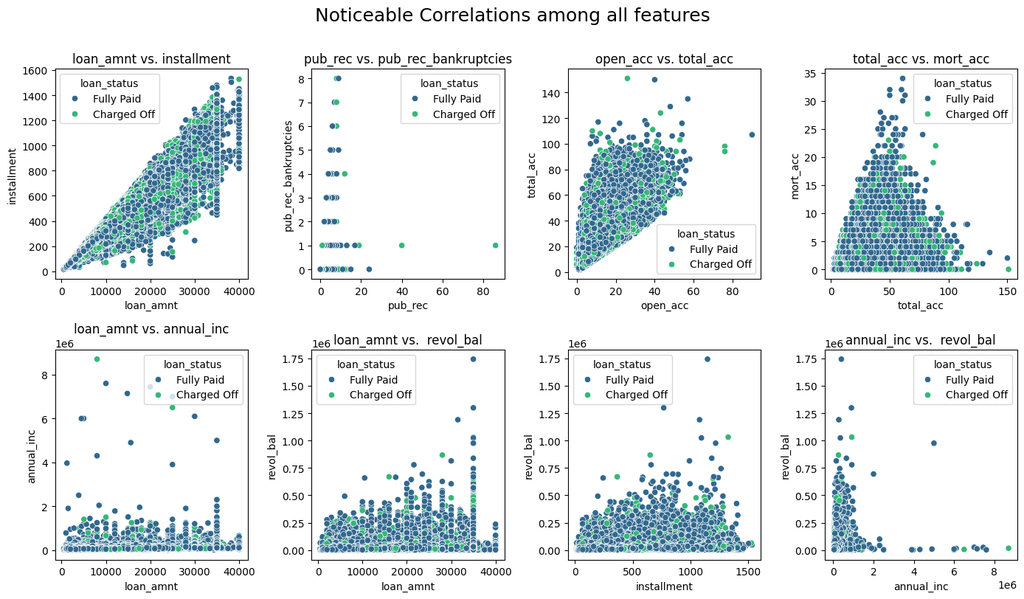

```python
plt.figure(figsize=(14, 8))
plt.subplot(2, 4, 1)
sns.scatterplot(x='loan_amnt', y='installment', hue='loan_status', data=df, palette = 'viridis')
plt.title("loan_amnt vs. installment")
plt.subplot(2, 4, 2)
sns.scatterplot(x='pub_rec', y='pub_rec_bankruptcies', hue='loan_status', data=df, palette = 'viridis')
plt.title("pub_rec vs. pub_rec_bankruptcies")
plt.subplot(2, 4, 3)
sns.scatterplot(x='open_acc', y='total_acc', hue='loan_status', data=df, palette = 'viridis')
plt.title("open_acc vs. total_acc")
plt.subplot(2, 4, 4)
sns.scatterplot(x='total_acc', y='mort_acc', hue='loan_status', data=df, palette = 'viridis')
plt.title("total_acc vs. mort_acc")
plt.subplot(2, 4, 5)
sns.scatterplot(x='loan_amnt', y='annual_inc', hue='loan_status', data=df, palette = 'viridis')
plt.title("loan_amnt vs. annual_inc")
plt.subplot(2, 4, 6)
sns.scatterplot(x='loan_amnt', y='revol_bal', hue='loan_status', data=df, palette = 'viridis')
plt.title("loan_amnt vs.  revol_bal")
plt.subplot(2, 4, 7)
sns.scatterplot(x='installment', y='revol_bal', hue='loan_status', data=df, palette = 'viridis')
plt.subplot(2, 4, 8)
sns.scatterplot(x='annual_inc', y='revol_bal', hue='loan_status', data=df, palette = 'viridis')
plt.title("annual_inc vs.  revol_bal")
plt.suptitle("Noticeable Correlations among all features", fontsize = 18, y = 1.01)
plt.tight_layout()
plt.show()
```

### Comparison of Median of each Numerical Feature by Loan Status

```python
numl_cols = df.select_dtypes(include=['int64','float64']).columns
print("Comparisons of Median values of each numerical features by loan status")
print("-" * 70)
for i in num_cols:
  print(f"Column Name: {i}")
  print(df.groupby('loan_status')[i].median())
  print("_" * 35)
  print()
```

```
Comparisons of Median values of each numerical features by loan status
----------------------------------------------------------------------
Column Name: loan_amnt
loan_status
Charged Off    14000.0
Fully Paid     12000.0
Name: loan_amnt, dtype: float64
___________________________________

Column Name: int_rate
loan_status
Charged Off    15.61
Fully Paid     12.99
Name: int_rate, dtype: float64
___________________________________

Column Name: installment
loan_status
Charged Off    399.06
Fully Paid     369.51
Name: installment, dtype: float64
___________________________________

Column Name: annual_inc
loan_status
Charged Off    59000.0
Fully Paid     65000.0
Name: annual_inc, dtype: float64
___________________________________

Column Name: dti
loan_status
Charged Off    19.34
Fully Paid     16.34
Name: dti, dtype: float64
___________________________________

Column Name: open_acc
loan_status
Charged Off    11.0
```

[output cut: 30 more lines]

```
___________________________________

Column Name: mort_acc
loan_status
Charged Off    1.0
Fully Paid     1.0
Name: mort_acc, dtype: float64
___________________________________

Column Name: pub_rec_bankruptcies
loan_status
Charged Off    0.0
Fully Paid     0.0
Name: pub_rec_bankruptcies, dtype: float64
___________________________________
```

### Box Plot for each Numerical Feature Vs. Loan Status - To compare Median Visually

[output not shown]

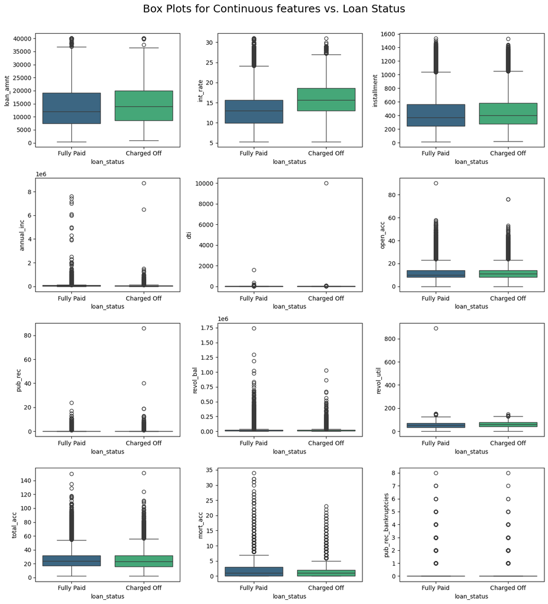

```python
num_cols = df.select_dtypes(include=['int64','float64']).columns
plt.figure(figsize=(13, 14))
for i, col in enumerate(num_cols):
  plt.subplot(4, 3, i+1)
  sns.boxplot(x='loan_status', y=col, data=df, palette = 'viridis')

plt.suptitle("Box Plots for Continuous features vs. Loan Status", fontsize = 18,y = 1.01)
plt.tight_layout()
plt.show()
```

- Column Name: loan_amnt Vs. loan_status
  1. Charged Off 14000.0
  2. Fully Paid 12000.0
  3. Loans that are charged off tend to have higher median amounts compared to fully paid loans.
- Column Name: int_rate Vs. loan_status
  1. Charged Off 15.61
  2. Fully Paid 12.99
  3. Charged off loans have higher median interest rates, indicating a potential higher risk profile
- Column Name: installment vs. loan_status
  1. Charged Off 399.06
  2. Fully Paid 369.51
  3. Charged off loans have higher median installment payments
- Column Name: annual_inc Vs. loan_status
  1. Charged Off 59000.0
  2. Fully Paid 65000.0
  3. Fully paid loans are associated with higher median annual incomes, suggesting better financial stability
- Column Name: dti Vs. loan_status
  1. Charged Off 19.34
  2. Fully Paid 16.34
  3. Charged off loans have a higher median DTI ratio, indicating higher debt burden relative to income.
- Column Name: open_acc Vs. loan_status
  1. Charged Off 11.0
  2. Fully Paid 10.0
  3. Charged off loans have a slightly higher median number of open accounts
- Column Name: pub_rec Vs. loan_status
  1. Charged Off 0.0
  2. Fully Paid 0.0
  3. Both loan statuses have a median of zero public records
- Column Name: revol_bal Vs. loan_status
  1. Charged Off 11277.0
  2. Fully Paid 11158.0
  3. Charged off loans have a slightly higher median revolving balance
- Column Name: revol_util Vs. loan_status
  1. Charged Off 59.3
  2. Fully Paid 53.7
  3. Charged off loans have higher median revolving utilization rates, suggesting higher credit usage
- Column Name: total_acc Vs. loan_status
  1. Charged Off 23.0
  2. Fully Paid 24.0
  3. Fully paid loans have a slightly higher median number of total accounts
- Column Name: mort_acc Vs. loan_status
  1. Charged Off 1.0
  2. Fully Paid 1.0
  3. Both loan statuses have the same median number of mortgage accounts
- Column Name: pub_rec_bankruptcies Vs. loan_status
  1. Charged Off 0.0
  2. Fully Paid 0.0
  3. Both loan statuses have a median of zero public record bankruptcies

### Insights

1. Higher Loan Amounts and Interest Rates: Charged off loans generally have higher median loan amounts and interest rates, which may indicate higher risk profiles.
2. Income and DTI Ratios: Fully paid loans are associated with higher median incomes and lower DTI ratios, suggesting better financial health.
3. Revolving Utilization: Higher median revolving utilization rates for charged off loans indicate higher levels of credit usage, which could be a risk factor

### Comparison of each Categorical Feature by Loan Status

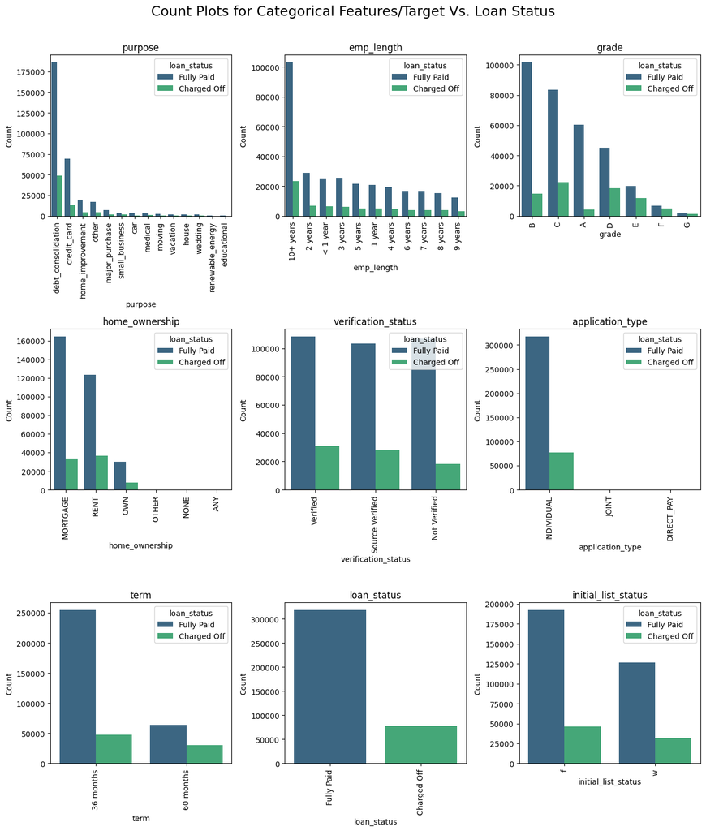

```python
obj_cols = unique_values[(unique_values['Type']=='object') & (unique_values['Unique Values'] < 35)].sort_values(by='Unique Values',ascending=False).index

n = (len(obj_cols) // 3) + (1 if len(obj_cols) % 3 > 0 else 0)

plt.figure(figsize=(13, 5 * n))

for j, col in enumerate(obj_cols,1):
    plt.subplot(n, 3, j)
    sns.countplot(data=df, x=col, hue = 'loan_status', order=df[col].value_counts().index, palette = 'viridis')
    plt.xticks(rotation=90)
    plt.ylabel('Count')
    plt.xlabel(col)
    plt.title(col)

plt.suptitle("Count Plots for Categorical Features/Target Vs. Loan Status", fontsize=18, y=1.01)
plt.tight_layout()
plt.show()
```

### Insights

1. Purpose: Debt consolidation is the most common purpose for both charged-off and fully paid loans, with a higher proportion of charged-off loans, indicating potential risk in this category.
2. Employment Length: Borrowers with over 10 years of employment are the most likely to both charge off and fully pay their loans, with a slightly higher proportion for fully paid loans.
3. Grade: Grade G has the highest proportion of "Charged Off" loans, whereas grade A has the highest proportion of "Fully Paid" loans, indicating that loans with better grades are more likely to be fully paid
4. Home Ownership: RENT has the highest proportion of charged-off loans, while MORTGAGE has the highest proportion of fully paid loans, suggesting that owning a home might be a positive indicator of loan repayment ability.
5. Verification Status: Loans that are Not Verified have the least proportions for "Charged Off" with a slightly higher proportion of fully paid loans than Verified ones
6. Application Type: Individual applications have higher proportions for both charged-off and fully paid loans
7. Term: Borrowers with 36-month terms have higher proportions of both "Charged Off" and "Fully Paid" loans compared to 60-month terms. However, the difference is more significant for "Fully Paid" loans
8. Loans listed as 'f' have the highest proportions for both categories, with a slightly higher proportion of fully paid loans.

## Data Pre-Processing

### 01. Checking for Duplicates

```python
df.duplicated().sum()
```

```
np.int64(0)
```

No duplicate record in the dataset

### 02. Missing Value Treatment

```python
missing_value = pd.DataFrame({'Type':df.dtypes,'Missing Value': df.isnull().sum(),'Percentage':(df.isnull().sum()/len(df))*100})
missing_value.sort_values(by = "Percentage", ascending = False)
```

|  | Type | Missing Value | Percentage |
| --- | --- | --- | --- |
| mort_acc | float64 | 37795 | 9.543469 |
| emp_title | object | 22927 | 5.789208 |
| emp_length | object | 18301 | 4.621115 |
| title | object | 1756 | 0.443401 |
| pub_rec_bankruptcies | float64 | 535 | 0.135091 |
| revol_util | float64 | 276 | 0.069692 |
| installment | float64 | 0 | 0.000000 |
| int_rate | float64 | 0 | 0.000000 |
| term | object | 0 | 0.000000 |
| grade | object | 0 | 0.000000 |
| loan_amnt | float64 | 0 | 0.000000 |
| verification_status | object | 0 | 0.000000 |
| annual_inc | float64 | 0 | 0.000000 |
| home_ownership | object | 0 | 0.000000 |
| sub_grade | object | 0 | 0.000000 |
| dti | float64 | 0 | 0.000000 |
| issue_d | object | 0 | 0.000000 |
| loan_status | object | 0 | 0.000000 |
| purpose | object | 0 | 0.000000 |
| pub_rec | float64 | 0 | 0.000000 |
| open_acc | float64 | 0 | 0.000000 |
| earliest_cr_line | object | 0 | 0.000000 |
| revol_bal | float64 | 0 | 0.000000 |
| initial_list_status | object | 0 | 0.000000 |
| total_acc | float64 | 0 | 0.000000 |
| application_type | object | 0 | 0.000000 |
| address | object | 0 | 0.000000 |

### Findings

1. High Missing Percentage (>5%): might significantly impact the analysis
- Columns: mort_acc, emp_title
- Action: Impute mort_acc with median and emp_title with mode.
2. Moderate Missing Percentage (1-5%):
- Column: emp_length
- Action: Impute with mode.
3. Low Missing Percentage (<1%): may have a lesser impact.
- Columns: title, pub_rec_bankruptcies, revol_util
- Action: Impute and with mode for title and pub_rec_bankruptcies median for revol_util.

### Imputing for mort_acc

```python
#Find the column which is highly coorelated with mort_acc

numerical_df = df.select_dtypes(include=['int64','float64'])
correlation = numerical_df.corr()
correlation['mort_acc'].sort_values(ascending=False)
```

|  | mort_acc |
| --- | --- |
| mort_acc | 1.000000 |
| total_acc | 0.381072 |
| annual_inc | 0.236320 |
| loan_amnt | 0.222315 |
| revol_bal | 0.194925 |
| installment | 0.193694 |
| open_acc | 0.109205 |
| pub_rec_bankruptcies | 0.027239 |
| pub_rec | 0.011552 |
| revol_util | 0.007514 |
| dti | -0.025439 |
| int_rate | -0.082583 |

**dtype:** float64

```python
# Find the median values by grouping total_acc
median_value = df.groupby('total_acc')['mort_acc'].median()
median_value
```

| total_acc | mort_acc |
| --- | --- |
| 2.0 | 0.0 |
| 3.0 | 0.0 |
| 4.0 | 0.0 |
| 5.0 | 0.0 |
| 6.0 | 0.0 |
| ... | ... |
| 124.0 | 1.0 |
| 129.0 | 1.0 |
| 135.0 | 3.0 |
| 150.0 | 2.0 |
| 151.0 | 0.0 |

118 rows × 1 columns

**dtype:** float64

```python
#Functiion to impute the mort_acc with median values
def impute_mort_acc(total_acc, mort_acc):
  if pd.isnull(mort_acc):
    return median_value[total_acc]
  else:
    return mort_acc
```

```python
df['mort_acc'] = df.apply(lambda x: impute_mort_acc(x['total_acc'],x['mort_acc']), axis=1)
```

### Imputing for emp_title, emp_lenth, title,pub_rec_bankruptcies with mode

```python
columns_to_impute = ['emp_title', 'emp_length', 'title', 'pub_rec_bankruptcies']
for column in columns_to_impute:
  print(f"{column}'s mode values: {df[column].mode()[0]}")
  df[column].fillna(df[column].mode()[0], inplace=True)
```

```
emp_title's mode values: Teacher
emp_length's mode values: 10+ years
title's mode values: Debt consolidation
```

```
pub_rec_bankruptcies's mode values: 0.0
```

### Imputing for revol_util with median

```python
df['revol_util'].fillna(df['revol_util'].median(),inplace= True)
```

### Sanity check - After Missing Value treatment

```python
missing_value = pd.DataFrame({'Type':df.dtypes,'Missing Value': df.isnull().sum(),'Percentage':(df.isnull().sum()/len(df))*100})
missing_value.sort_values(by = "Percentage", ascending = False)
```

|  | Type | Missing Value | Percentage |
| --- | --- | --- | --- |
| loan_amnt | float64 | 0 | 0.0 |
| term | object | 0 | 0.0 |
| int_rate | float64 | 0 | 0.0 |
| installment | float64 | 0 | 0.0 |
| grade | object | 0 | 0.0 |
| sub_grade | object | 0 | 0.0 |
| emp_title | object | 0 | 0.0 |
| emp_length | object | 0 | 0.0 |
| home_ownership | object | 0 | 0.0 |
| annual_inc | float64 | 0 | 0.0 |
| verification_status | object | 0 | 0.0 |
| issue_d | object | 0 | 0.0 |
| loan_status | object | 0 | 0.0 |
| purpose | object | 0 | 0.0 |
| title | object | 0 | 0.0 |
| dti | float64 | 0 | 0.0 |
| earliest_cr_line | object | 0 | 0.0 |
| open_acc | float64 | 0 | 0.0 |
| pub_rec | float64 | 0 | 0.0 |
| revol_bal | float64 | 0 | 0.0 |
| revol_util | float64 | 0 | 0.0 |
| total_acc | float64 | 0 | 0.0 |
| initial_list_status | object | 0 | 0.0 |
| application_type | object | 0 | 0.0 |
| mort_acc | float64 | 0 | 0.0 |
| pub_rec_bankruptcies | float64 | 0 | 0.0 |
| address | object | 0 | 0.0 |

### 03. Outlier Detection

### Visual Method

[output not shown]

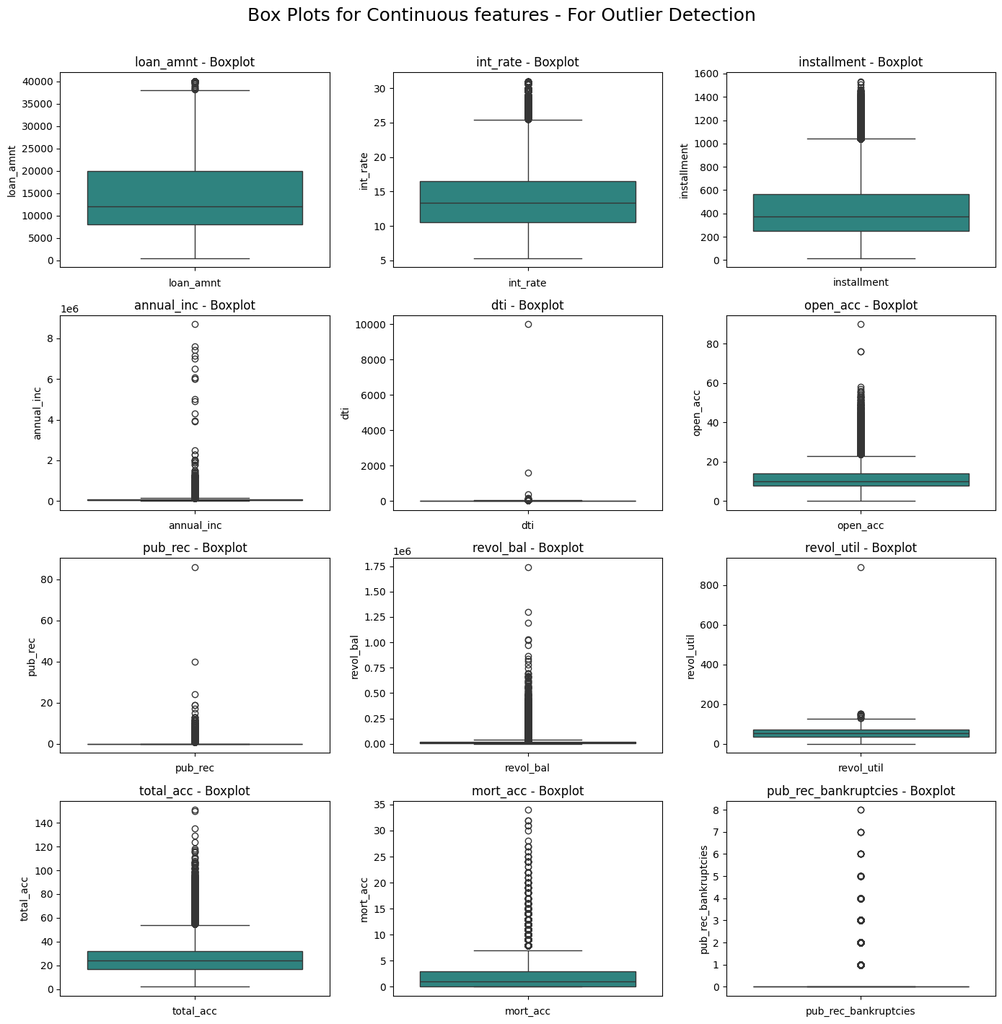

```python
num_cols = df.select_dtypes(include=['int64','float64']).columns

plt.figure(figsize = (14,14))
for i,col in enumerate(num_cols,1) :
  plt.subplot(4,3,i)
  sns.boxplot(df[col],palette = 'viridis')
  plt.xlabel(col)
  plt.title(f'{col} - Boxplot')

plt.suptitle("Box Plots for Continuous features - For Outlier Detection", fontsize = 18,y = 1.01)
plt.tight_layout()
plt.show()
```

### Non-Visual Method

```python
def detect_outliers(col):
  Q1 = np.quantile(df[col],0.25)
  Q2 = np.quantile(df[col],0.50)
  Q3 = np.quantile(df[col],0.75)
  IQR = Q3 - Q1
  lower_bound = max(df[col].min(), Q1 - 1.5 * IQR)
  upper_bound = min(df[col].max(), Q3 + 1.5 * IQR)
  outliers = df[(df[col] < lower_bound) | (df[col] > upper_bound)]
  percent_outliers = (len(outliers) / len(df)) * 100
  print(f"For Column : {col}")
  print(f"Min Value : {df[col].min()}")
  print(f"Max Value : {df[col].max()}")
  print(f"Lower Bound : {lower_bound}")
  print(f"Q1 : {Q1}")
  print(f"Q2 i.e. Median : {Q2}")
  print(f"Q3 : {Q3}")
  print(f"Upper Bound : {upper_bound}")
  print(f"IQR : {IQR}")
  print(f"Percentage of Outliers in column {col} : {round(percent_outliers,2)}%")
  #return outliers
```

```python
num_cols = df.select_dtypes(include=['int64','float64']).columns
for col in num_cols:
  detect_outliers(col)
  print("_" * 50)
```

```
For Column : loan_amnt
Min Value : 500.0
Max Value : 40000.0
Lower Bound : 500.0
Q1 : 8000.0
Q2 i.e. Median : 12000.0
Q3 : 20000.0
Upper Bound : 38000.0
IQR : 12000.0
Percentage of Outliers in column loan_amnt : 0.05%
__________________________________________________
For Column : int_rate
Min Value : 5.32
Max Value : 30.99
Lower Bound : 5.32
Q1 : 10.49
Q2 i.e. Median : 13.33
Q3 : 16.49
Upper Bound : 25.489999999999995
IQR : 5.999999999999998
Percentage of Outliers in column int_rate : 0.95%
__________________________________________________
For Column : installment
Min Value : 16.08
Max Value : 1533.81
Lower Bound : 16.08
Q1 : 250.33
Q2 i.e. Median : 375.43
Q3 : 567.3
Upper Bound : 1042.7549999999999
IQR : 316.9699999999999
Percentage of Outliers in column installment : 2.84%
__________________________________________________
For Column : annual_inc
Min Value : 0.0
Max Value : 8706582.0
Lower Bound : 0.0
Q1 : 45000.0
Q2 i.e. Median : 64000.0
Q3 : 90000.0
```

[output cut: 77 more lines]

```
Upper Bound : 7.5
IQR : 3.0
Percentage of Outliers in column mort_acc : 1.73%
__________________________________________________
For Column : pub_rec_bankruptcies
Min Value : 0.0
Max Value : 8.0
Lower Bound : 0.0
Q1 : 0.0
Q2 i.e. Median : 0.0
Q3 : 0.0
Upper Bound : 0.0
IQR : 0.0
Percentage of Outliers in column pub_rec_bankruptcies : 11.39%
__________________________________________________
```

### Findings

1. Percentage of Outliers in column pub_rec : 14.58%
2. Percentage of Outliers in column pub_rec_bankruptcies : 11.39%
3. Percentage of Outliers in column revol_bal : 5.37%
4. Percentage of Outliers in column annual_inc : 4.22%
5. Percentage of Outliers in column installment : 2.84%
6. Percentage of Outliers in column open_acc : 2.6%
7. Percentage of Outliers in column total_acc : 2.15%
8. Percentage of Outliers in column mort_acc : 1.73%
9. Percentage of Outliers in column int_rate : 0.95%
10. Percentage of Outliers in column dti : 0.07%
11. Percentage of Outliers in column loan_amnt : 0.05%
12. Percentage of Outliers in column revol_util : 0.0%

According to the nature of your dataset, which includes financial data with variables such as loan amounts, interest rates, and annual income, it is important to choose an outlier treatment method that is both effective and appropriate for the characteristics of this data. Financial data often contains natural variability and can have significant outliers due to varying customer profiles

### To choose the appropriate quantile threshold (0.75, 0.95, 0.99),

1. 0.75 Quantile (25th percentile): Using this quantile could be too restrictive and may not capture a broad range of outliers, potentially removing too many valid data points.
2. 0.95 Quantile (95th percentile): This is less restrictive and allows for a broader range of data while addressing most extreme outliers
3. 0.99 Quantile (99th percentile): This is useful only if you want to preserve as much data as possible and only cap the most extreme outliers.

```python
'''def detect_outliers(col):
  Q1 = np.quantile(df[col],0.25)
  Q3 = np.quantile(df[col],0.75)
  IQR = Q3 - Q1
  lower_bound = max(df[col].min(), Q1 - 1.5 * IQR)
  upper_bound = min(df[col].max(), Q3 + 1.5 * IQR)
  outliers = df[(df[col] < lower_bound) | (df[col] > upper_bound)]
  return outliers'''
```

[output not shown]

### 04. Outlier Treatment - Quantile-Based Capping

Note : Removing the values greater than upper bound only our dataset does not have any negative value

```python
def cap_outliers(df, column, quantile=0.95):
  upper_bound = df[column].quantile(quantile)
  df[column] = np.where(df[column] > upper_bound, upper_bound, df[column])
  return df
```

```python
# Creating a deep copy for backup
df_cleaned = df.copy()
```

```python
# Apply the cap_outliers function to each numerical column
num_cols = df.select_dtypes(include=['int64','float64']).columns
for col in num_cols:
  df_cleaned = cap_outliers(df_cleaned, col, 0.95)
```

### 05. Feature Engineering

```python
unique_values = pd.DataFrame({'Type':df_cleaned.dtypes,'Unique Values':df_cleaned.nunique()})
unique_values.sort_values(by='Unique Values',ascending=False)
```

|  | Type | Unique Values |
| --- | --- | --- |
| address | object | 393700 |
| emp_title | object | 173105 |
| installment | float64 | 51626 |
| title | object | 48816 |
| revol_bal | float64 | 39596 |
| annual_inc | float64 | 25728 |
| dti | float64 | 3159 |
| loan_amnt | float64 | 1207 |
| revol_util | float64 | 986 |
| earliest_cr_line | object | 684 |
| int_rate | float64 | 464 |
| issue_d | object | 115 |
| total_acc | float64 | 46 |
| sub_grade | object | 35 |
| open_acc | float64 | 22 |
| purpose | object | 14 |
| emp_length | object | 11 |
| mort_acc | float64 | 10 |
| grade | object | 7 |
| home_ownership | object | 6 |
| verification_status | object | 3 |
| application_type | object | 3 |
| term | object | 2 |
| pub_rec | float64 | 2 |
| loan_status | object | 2 |
| initial_list_status | object | 2 |
| pub_rec_bankruptcies | float64 | 2 |

```python
unique_values[(unique_values['Type']=='float64') & (unique_values['Unique Values'] < 5)].sort_values(by='Unique Values',ascending=False)
```

|  | Type | Unique Values |
| --- | --- | --- |
| pub_rec | float64 | 2 |
| pub_rec_bankruptcies | float64 | 2 |

### 05.1 Converting pub_rec and pub_rec_bankruptcies into categorical feature

```python
categorical_cols = ['pub_rec', 'pub_rec_bankruptcies']
for col in categorical_cols:
  df_cleaned[col] = df_cleaned[col].astype('category')
```

### 05.2 Splitting issue_d into issue_year and issue_month

```python
df_cleaned['issue_d'] = pd.to_datetime(df_cleaned['issue_d'])

df_cleaned['issue_month'] = df_cleaned['issue_d'].dt.month.astype('category')
df_cleaned['issue_year'] = df_cleaned['issue_d'].dt.year.astype('category')
```

### 05.3 Splitting earliest_cr_line into earliest_cr_line_year and earliest_cr_line_month

```python
df_cleaned['earliest_cr_line'] = pd.to_datetime(df_cleaned['earliest_cr_line'])

df_cleaned['earliest_cr_line_month'] = df_cleaned['earliest_cr_line'].dt.month.astype('category')
df_cleaned['earliest_cr_line_year'] = df_cleaned['earliest_cr_line'].dt.year.astype('category')
```

### 05.4 Splitting Text address to State and Zip_code

```python
df_cleaned['state']= df_cleaned['address'].apply(lambda x: x.strip()[-8:-6]).astype('category')
df_cleaned['zip_code']= df_cleaned['address'].apply(lambda x: x.strip()[-5:]).astype('category')
df_cleaned[['state','zip_code']]
```

|  | state | zip_code |
| --- | --- | --- |
| 0 | OK | 22690 |
| 1 | SD | 05113 |
| 2 | WV | 05113 |
| 3 | MA | 00813 |
| 4 | VA | 11650 |
| ... | ... | ... |
| 396025 | DC | 30723 |
| 396026 | LA | 05113 |
| 396027 | NY | 70466 |
| 396028 | FL | 29597 |
| 396029 | AR | 48052 |

396030 rows × 2 columns

```python
df_cleaned.drop(['issue_d', 'earliest_cr_line','address'], axis=1, inplace=True)
```

```python
# Sanity Check
df_cleaned.info()
```

```
<class 'pandas.core.frame.DataFrame'>
RangeIndex: 396030 entries, 0 to 396029
Data columns (total 30 columns):
 #   Column                  Non-Null Count   Dtype
---  ------                  --------------   -----
 0   loan_amnt               396030 non-null  float64
 1   term                    396030 non-null  object
 2   int_rate                396030 non-null  float64
 3   installment             396030 non-null  float64
 4   grade                   396030 non-null  object
 5   sub_grade               396030 non-null  object
 6   emp_title               396030 non-null  object
 7   emp_length              396030 non-null  object
 8   home_ownership          396030 non-null  object
 9   annual_inc              396030 non-null  float64
```

[output cut: 22 more lines]

```python
#Sanity Check - Null value in new columns
df_cleaned[['issue_month','issue_year','earliest_cr_line_month','earliest_cr_line_year','state','zip_code']].isnull().sum()
```

|  | 0 |
| --- | --- |
| issue_month | 0 |
| issue_year | 0 |
| earliest_cr_line_month | 0 |
| earliest_cr_line_year | 0 |
| state | 0 |
| zip_code | 0 |

**dtype:** int64

### 06. Encoding

```python
unique_values = pd.DataFrame({'Type':df_cleaned.dtypes,'Unique Values':df_cleaned.nunique()})
unique_values[(unique_values['Type']=='object') | (unique_values['Type']=='category')].sort_values(by='Unique Values',ascending=False)
```

|  | Type | Unique Values |
| --- | --- | --- |
| emp_title | object | 173105 |
| title | object | 48816 |
| earliest_cr_line_year | category | 65 |
| state | category | 54 |
| sub_grade | object | 35 |
| purpose | object | 14 |
| earliest_cr_line_month | category | 12 |
| issue_month | category | 12 |
| emp_length | object | 11 |
| issue_year | category | 10 |
| zip_code | category | 10 |
| grade | object | 7 |
| home_ownership | object | 6 |
| application_type | object | 3 |
| verification_status | object | 3 |
| term | object | 2 |
| initial_list_status | object | 2 |
| pub_rec | category | 2 |
| loan_status | object | 2 |
| pub_rec_bankruptcies | category | 2 |

### 06.1 Target = loan_status : LabelEncoding

- As it is Ordinal in nature

```python
from sklearn.preprocessing import LabelEncoder
```

```python
label_encoder = LabelEncoder()
df_cleaned['loan_status'] = label_encoder.fit_transform(df_cleaned['loan_status'])
print(df_cleaned['loan_status'].value_counts())
```

```
loan_status
1    318357
0     77673
Name: count, dtype: int64
```

### Performing Chi Square test of indewpendence to determine the Object / Catergorical Columns irrelveant columns to detemine Loan Status

```python
from scipy.stats import chi2_contingency
```

```python
#Ho: INDEPENDENT
#Ha: NOT INDEPENDENT
```

```python
print("OBSERVATION:")
columns = df_cleaned.select_dtypes(include=['category','object']).columns
for col in columns:
  observed = pd.crosstab(df_cleaned[col], df_cleaned['loan_status'])
  chi_stat, p_value, dof, exp_freq = chi2_contingency(observed)
  # Conclusion
  if p_value < 0.05:
    result = "DEPENDENT with loan status"
  else:
    result = "INDEPENDENT with loan status"
    print(f"- Drop the {col} since it is {result}")
```

```
OBSERVATION:
- Drop the emp_title since it is INDEPENDENT with loan status
- Drop the title since it is INDEPENDENT with loan status
- Drop the earliest_cr_line_month since it is INDEPENDENT with loan status
- Drop the state since it is INDEPENDENT with loan status
```

### Dropping the columns on which Loan Status does not depend Significantly

```python
df_cleaned.drop(['emp_title','title','earliest_cr_line_month','state'], axis = 1, inplace = True)
```

```python
unique_values = pd.DataFrame({'Type':df_cleaned.dtypes,'Unique Values':df_cleaned.nunique()})
unique_values.sort_values(by='Unique Values',ascending=False)
```

|  | Type | Unique Values |
| --- | --- | --- |
| installment | float64 | 51626 |
| revol_bal | float64 | 39596 |
| annual_inc | float64 | 25728 |
| dti | float64 | 3159 |
| loan_amnt | float64 | 1207 |
| revol_util | float64 | 986 |
| int_rate | float64 | 464 |
| earliest_cr_line_year | category | 65 |
| total_acc | float64 | 46 |
| sub_grade | object | 35 |
| open_acc | float64 | 22 |
| purpose | object | 14 |
| issue_month | category | 12 |
| emp_length | object | 11 |
| zip_code | category | 10 |
| issue_year | category | 10 |
| mort_acc | float64 | 10 |
| grade | object | 7 |
| home_ownership | object | 6 |
| verification_status | object | 3 |
| application_type | object | 3 |
| term | object | 2 |
| pub_rec | category | 2 |
| loan_status | int64 | 2 |
| pub_rec_bankruptcies | category | 2 |
| initial_list_status | object | 2 |

```python
unique_values = pd.DataFrame({'Type':df_cleaned.dtypes,'Unique Values':df_cleaned.nunique()})
unique_values[((unique_values['Type']=='object') | (unique_values['Type']=='category')) & (unique_values['Unique Values']==2)].sort_values(by='Unique Values',ascending=False)
```

|  | Type | Unique Values |
| --- | --- | --- |
| term | object | 2 |
| pub_rec | category | 2 |
| initial_list_status | object | 2 |
| pub_rec_bankruptcies | category | 2 |

```python
unique_values = pd.DataFrame({'Type':df_cleaned.dtypes,'Unique Values':df_cleaned.nunique()})
unique_values[((unique_values['Type']=='object') | (unique_values['Type']=='category')) & (unique_values['Unique Values']>2)].sort_values(by='Unique Values',ascending=False)
```

|  | Type | Unique Values |
| --- | --- | --- |
| earliest_cr_line_year | category | 65 |
| sub_grade | object | 35 |
| purpose | object | 14 |
| issue_month | category | 12 |
| emp_length | object | 11 |
| zip_code | category | 10 |
| issue_year | category | 10 |
| grade | object | 7 |
| home_ownership | object | 6 |
| application_type | object | 3 |
| verification_status | object | 3 |

### The Columns to be Performed under One Hot Encoding(No inherent order):

- home_ownership ('ANY', 'MORTGAGE', 'NONE', 'OTHER', 'OWN', 'RENT')
- verification_status ('Not Verified', 'Source Verified', 'Verified')
- purpose ('car', 'credit_card', ..., 'wedding')
- application_type ('DIRECT_PAY', 'INDIVIDUAL', 'JOINT')
- zip_code ( '00813', '05113', ..., '93700')

### The Columns to be Performed under Lable Encoding(Binary or Order matters):

- term ('36 months', ' 60 months')
- pub_rec (0.0, 1.0)
- pub_rec_bankruptcies (0.0, 1.0)
- initial_list_status ('f', 'w')
- grade ('A', 'B', 'C', 'D', 'E', 'F', 'G')
- sub_grade ('A1', 'A2', ..., 'G5)
- emp_length ('1 year', '10+ years', ..., '< 1 year')
- issue_month (1 to 12)
- issue_year (10 Categories)
- earliest_cr_line_year (65 Categiries

```python
OHE_columns = df_cleaned[['home_ownership','verification_status','purpose','application_type','zip_code']]
label_columns = df_cleaned[['term','pub_rec','pub_rec_bankruptcies','initial_list_status','grade','sub_grade','emp_length','issue_month','issue_year','earliest_cr_line_year']]
num_cols = df_cleaned.select_dtypes(include=['int64','float64'])
```

```python
num_cols.head(3)
```

|  | loan_amnt | int_rate | installment | annual_inc | loan_status | dti | open_acc | revol_bal | revol_util | total_acc | mort_acc |
| --- | --- | --- | --- | --- | --- | --- | --- | --- | --- | --- | --- |
| 0 | 10000.0 | 11.44 | 329.48 | 117000.0 | 1 | 26.24 | 16.0 | 36369.0 | 41.8 | 25.0 | 0.0 |
| 1 | 8000.0 | 11.99 | 265.68 | 65000.0 | 1 | 22.05 | 17.0 | 20131.0 | 53.3 | 27.0 | 3.0 |
| 2 | 15600.0 | 10.49 | 506.97 | 43057.0 | 1 | 12.79 | 13.0 | 11987.0 | 92.0 | 26.0 | 0.0 |

```python
OHE_columns.head(3)
```

|  | home_ownership | verification_status | purpose | application_type | zip_code |
| --- | --- | --- | --- | --- | --- |
| 0 | RENT | Not Verified | vacation | INDIVIDUAL | 22690 |
| 1 | MORTGAGE | Not Verified | debt_consolidation | INDIVIDUAL | 05113 |
| 2 | RENT | Source Verified | credit_card | INDIVIDUAL | 05113 |

```python
label_columns.head(3)
```

|  | term | pub_rec | pub_rec_bankruptcies | initial_list_status | grade | sub_grade | emp_length | issue_month | issue_year | earliest_cr_line_year |
| --- | --- | --- | --- | --- | --- | --- | --- | --- | --- | --- |
| 0 | 36 months | 0.0 | 0.0 | w | B | B4 | 10+ years | 1 | 2015 | 1990 |
| 1 | 36 months | 0.0 | 0.0 | f | B | B5 | 4 years | 1 | 2015 | 2004 |
| 2 | 36 months | 0.0 | 0.0 | f | B | B3 | < 1 year | 1 | 2015 | 2007 |

### 06.2 Performing One Hot Encoding for 'home_ownership', 'verification_status', 'purpose', 'application_type', 'zip_code'

```python
OHE_columns.columns
```

```
Index(['home_ownership', 'verification_status', 'purpose', 'application_type',
       'zip_code'],
      dtype='object')
```

```python
df_encoded = pd.get_dummies(df_cleaned, columns = OHE_columns.columns)
# Convert boolean columns to integer
bool_columns = df_encoded.select_dtypes(include='bool').columns
df_encoded[bool_columns] = df_encoded[bool_columns].astype(int)
```

```python
df_encoded.info()
```

```
<class 'pandas.core.frame.DataFrame'>
RangeIndex: 396030 entries, 0 to 396029
Data columns (total 57 columns):
 #   Column                               Non-Null Count   Dtype
---  ------                               --------------   -----
 0   loan_amnt                            396030 non-null  float64
 1   term                                 396030 non-null  object
 2   int_rate                             396030 non-null  float64
 3   installment                          396030 non-null  float64
 4   grade                                396030 non-null  object
 5   sub_grade                            396030 non-null  object
 6   emp_length                           396030 non-null  object
 7   annual_inc                           396030 non-null  float64
 8   loan_status                          396030 non-null  int64
 9   dti                                  396030 non-null  float64
```

[output cut: 49 more lines]

### 06.3 Performing Label Encoding for 'term', 'pub_rec', 'pub_rec_bankruptcies','initial_list_status', 'grade', 'sub_grade' , 'emp_length', 'issue_month', 'issue_year', 'earliest_cr_line_year'

```python
from sklearn.preprocessing import LabelEncoder
```

```python
for col in label_columns:
# Initialize the LabelEncoder
  label_encoder = LabelEncoder()
  df_encoded[col] = label_encoder.fit_transform(df_encoded[col])
```

```python
df_encoded.info()
```

```
<class 'pandas.core.frame.DataFrame'>
RangeIndex: 396030 entries, 0 to 396029
Data columns (total 57 columns):
 #   Column                               Non-Null Count   Dtype
---  ------                               --------------   -----
 0   loan_amnt                            396030 non-null  float64
 1   term                                 396030 non-null  int64
 2   int_rate                             396030 non-null  float64
 3   installment                          396030 non-null  float64
 4   grade                                396030 non-null  int64
 5   sub_grade                            396030 non-null  int64
 6   emp_length                           396030 non-null  int64
 7   annual_inc                           396030 non-null  float64
 8   loan_status                          396030 non-null  int64
 9   dti                                  396030 non-null  float64
```

[output cut: 49 more lines]

```python
df_encoded.head(3)
```

|  | loan_amnt | term | int_rate | installment | grade | sub_grade | emp_length | annual_inc | loan_status | dti | ... | zip_code_00813 | zip_code_05113 | zip_code_11650 | zip_code_22690 | zip_code_29597 | zip_code_30723 | zip_code_48052 | zip_code_70466 | zip_code_86630 | zip_code_93700 |
| --- | --- | --- | --- | --- | --- | --- | --- | --- | --- | --- | --- | --- | --- | --- | --- | --- | --- | --- | --- | --- | --- |
| 0 | 10000.0 | 0 | 11.44 | 329.48 | 1 | 8 | 1 | 117000.0 | 1 | 26.24 | ... | 0 | 0 | 0 | 1 | 0 | 0 | 0 | 0 | 0 | 0 |
| 1 | 8000.0 | 0 | 11.99 | 265.68 | 1 | 9 | 4 | 65000.0 | 1 | 22.05 | ... | 0 | 1 | 0 | 0 | 0 | 0 | 0 | 0 | 0 | 0 |
| 2 | 15600.0 | 0 | 10.49 | 506.97 | 1 | 7 | 10 | 43057.0 | 1 | 12.79 | ... | 0 | 1 | 0 | 0 | 0 | 0 | 0 | 0 | 0 | 0 |

3 rows × 57 columns

### 07. Train - Validation - Test Data Split

```python
Y = df_encoded['loan_status']
X = df_encoded.drop('loan_status', axis = 1)
X.shape, Y.shape
```

```
((396030, 56), (396030,))
```

```python
from numpy.random.mtrand import random_sample
#(Train + Validation) & Test Data Split - Train +Validation = 80% & Test =20%
from sklearn.model_selection import train_test_split
X_tr_cv, X_test, Y_tr_cv, Y_test = train_test_split(X, Y, test_size=0.2, random_state=100)
#Train + Validation Data - Split into Training & Validation : Train - 80% & Validation 20%
X_train, X_val, Y_train, Y_val = train_test_split(X_tr_cv, Y_tr_cv, test_size=0.25,random_state=100)
```

```python
print(f"Shape of X_train : {X_train.shape}")
print(f"Shape of Y_train : {Y_train.shape}")
print(f"Shape of X_val : {X_val.shape}")
print(f"Shape of Y_val : {Y_val.shape}")
print(f"Shape of X_test : {X_test.shape}")
print(f"Shape of Y_test : {Y_test.shape}")
```

```
Shape of X_train : (237618, 56)
Shape of Y_train : (237618,)
Shape of X_val : (79206, 56)
Shape of Y_val : (79206,)
Shape of X_test : (79206, 56)
Shape of Y_test : (79206,)
```

```python
#Checking Train - Validation - Test Data proportion
print(f"Percentage of Train Data : {round(len(X_train)/len(X)*100,2)}%")
print(f"Percentage of Train Data : {round(len(X_val)/len(X)*100,2)}%")
print(f"Percentage of Train Data : {round(len(X_test)/len(X)*100,2)}%")
```

```
Percentage of Train Data : 60.0%
Percentage of Train Data : 20.0%
Percentage of Train Data : 20.0%
```

### 08. Feature Scaling

### MinMaxScaler :

- As data is not Gaussian and we have performed outlier treatment, hence we can scale our data using MinMaxScaler

```python
from sklearn.preprocessing import MinMaxScaler
```

```python
scaler = MinMaxScaler()
```

```python
X_train_scaled = scaler.fit_transform(X_train)
X_val_scaled = scaler.fit_transform(X_val)
X_test_scaled = scaler.fit_transform(X_test)
```

### 09. Model Building

### 09.1 Classification Matrix

1. High Precision Scenario: If the financial institution is conservative and risk-averse, it might prioritize precision to ensure that loans are only granted to borrowers with a high likelihood of repaying. This approach minimizes potential losses from defaults but may result in rejecting some good borrowers (false negatives).
2. High Recall Scenario: If the institution is focused on growth and can tolerate a certain level of risk, it might prioritize recall to maximize the identification of creditworthy borrowers. This approach may involve more false positives but ensures that fewer good borrowers are missed.
- Balanced Approach: Often, a balanced approach considering both precision and recall is ideal.The F1 score, which is the harmonic mean of precision and recall, can provide a single metric to balance these two aspects. Additionally, setting appropriate thresholds or using cost-sensitive learning approaches can help balance the trade-offs between precision and recall.

### 09.2 Checking Data imbalance

```python
(df['loan_status'].value_counts(normalize=True).round(4)*100)
```

| loan_status | proportion |
| --- | --- |
| Fully Paid | 80.39 |
| Charged Off | 19.61 |

**dtype:** float64

```python
(Y_train.value_counts(normalize=True).round(4)*100)
```

| loan_status | proportion |
| --- | --- |
| 1 | 80.42 |
| 0 | 19.58 |

**dtype:** float64

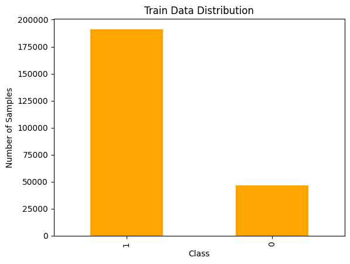

```python
Y_train.value_counts().plot(kind='bar', color = 'orange')
plt.xlabel('Class')
plt.ylabel('Number of Samples')
plt.title('Train Data Distribution')
plt.show()
```

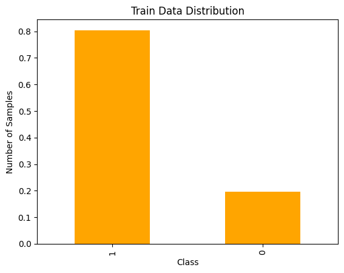

```python
Y_train.value_counts(normalize = True).plot(kind='bar', color = 'orange')
plt.xlabel('Class')
plt.ylabel('Number of Samples')
plt.title('Train Data Distribution')
plt.show()
```

- Since the proportion of data is around 80% for 1 and 20% for class 0, we can conclude that the data is imbalanced.

### 09.3 Base Model - Logistic Regression

```python
#Logistic Regression
from sklearn.linear_model import LogisticRegression
# Initialize the Logistic Regression model
base_model = LogisticRegression(random_state=1)
# Fit the model on the training data
base_model.fit(X_train_scaled, Y_train)
```

```
LogisticRegression(random_state=1)
```

```python
from sklearn.metrics import accuracy_score, precision_score, recall_score, f1_score,confusion_matrix,ConfusionMatrixDisplay,classification_report

# Function to Predict the values
def model_performance(model, X_train_scaled, Y_train, X_val_scaled, Y_val):
  Y_pred_train = model.predict(X_train_scaled)
  Y_pred_val = model.predict(X_val_scaled)
  print(f"Training Accuracy: {round(accuracy_score(Y_train, Y_pred_train),2)}")
  print(f"Training Precision: {round(precision_score(Y_train, Y_pred_train),2)}")
  print(f"Training Recall: {round(recall_score(Y_train, Y_pred_train),2)}")
  print(f"Training F1 Score: {round(f1_score(Y_train, Y_pred_train),2)}")
  print()
  print(f"Test Accuracy: {round(accuracy_score(Y_val, Y_pred_val),2)}")
  print(f"Test Precision: {round(precision_score(Y_val, Y_pred_val),2)}")
  print(f"Test Recall: {round(recall_score(Y_val, Y_pred_val),2)}")
  print(f"Test F1 Score: {round(f1_score(Y_val, Y_pred_val),2)}")
  # Confusion Matrix
  print("\nConfusion Matrix:")
  cm = confusion_matrix(Y_val, Y_pred_val)
  print(cm)
  ConfusionMatrixDisplay(cm).plot()
  plt.title('Confusion Matrix')
  plt.show()
  # Classification Report
  print("\nClassification Report:")
  print(classification_report(Y_val, Y_pred_val))
```

```
Base Model Performance:
-------------------------
Training Accuracy: 0.89
Training Precision: 0.89
Training Recall: 0.99
Training F1 Score: 0.93

Test Accuracy: 0.89
Test Precision: 0.88
Test Recall: 0.99
Test F1 Score: 0.93

Confusion Matrix:
[[ 7437  8226]
 [  636 62907]]
```

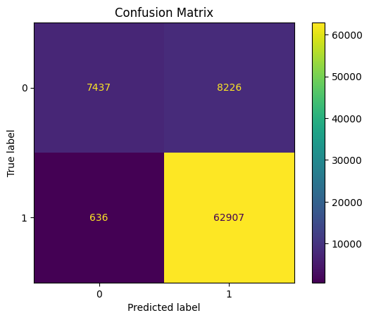

```
Classification Report:
              precision    recall  f1-score   support

           0       0.92      0.47      0.63     15663
           1       0.88      0.99      0.93     63543

    accuracy                           0.89     79206
   macro avg       0.90      0.73      0.78     79206
weighted avg       0.89      0.89      0.87     79206
```

```python
print("Base Model Performance:")
print("-" * 25)
model_performance(base_model, X_train_scaled, Y_train, X_val_scaled, Y_val)
```

### Model Performance - Insights

- High recall (0.99) suggests the model is very good at identifying positive cases.
- Precision (0.89) indicates a good proportion of predicted positives are true positives.
- High F1 score (0.93) reflects a strong balance between precision and recall.

### 09.4 Precision - Recall Curve

- as the data is imbalanced (We can not use ROC i.e. Reciever Operating Curve)

```python
#Hyperparameter Tuning of Threshold
from sklearn.metrics import precision_recall_curve, auc
```

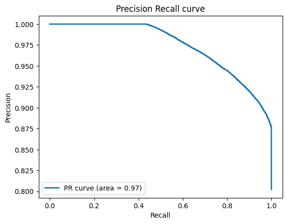

```python
# Compute predicted probabilities
Y_pred_prob_val = base_model.predict_proba(X_val_scaled)[:,1]
# Get precision, recall, and thresholds
precision, recall, thres = precision_recall_curve(Y_val, Y_pred_prob_val)
auc_score = auc(recall, precision)
# Plot PR Curve
plt.figure()
plt.plot(recall, precision, lw=2, label='PR curve (area = %0.2f)' % auc_score)
plt.xlabel('Recall')
plt.ylabel('Precision')
plt.title('Precision Recall curve')
plt.legend(loc="lower left")
plt.show()
```

### From the business domain we should ask about the acceptable recall.

- Lets us consider recall should be greater than 0.8

```python
# Find the Optimal threshold
x = 0.8 # Input based on Business Requirement
recall > x
# Find the correct threshold when recall > 0.8 and maximum precision
Optimal_threshold = thres[np.argmax(precision[recall > 0.8])]
max_precision = precision[np.argmax(precision[recall > 0.8])]
auc_score = auc(recall, precision)
print(f"For Recall > {x},")
print(f"Maximum Precision is: {(max_precision).round(2)}")
print(f"Optimal Threshold is: {(Optimal_threshold).round(2)}")
print(f"AUC Score: {(auc_score).round(2)}")
```

```
For Recall > 0.8,
Maximum Precision is: 0.94
Optimal Threshold is: 0.81
AUC Score: 0.97
```

```
Base Model Performance after customizing the threshold:
----------------------------------------------------------
Test Accuracy: 0.8
Test Precision: 0.94
Test Recall: 0.8
Test F1 Score: 0.87

Confusion Matrix:
[[12674  2989]
 [12673 50870]]
```

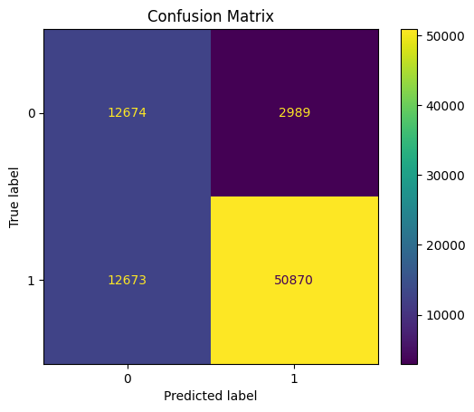

```python
#Model Performance after custamizing the threshold:
Y_pred_custom_threshold = (Y_pred_prob_val >= Optimal_threshold).astype(int)
print("Base Model Performance after customizing the threshold:")
print("-" * 58)
print(f"Test Accuracy: {round(accuracy_score(Y_val, Y_pred_custom_threshold),2)}")
print(f"Test Precision: {round(precision_score(Y_val, Y_pred_custom_threshold),2)}")
print(f"Test Recall: {round(recall_score(Y_val, Y_pred_custom_threshold),2)}")
print(f"Test F1 Score: {round(f1_score(Y_val, Y_pred_custom_threshold),2)}")
# Confusion Matrix
print("\nConfusion Matrix:")
cm = confusion_matrix(Y_val, Y_pred_custom_threshold)
print(cm)
ConfusionMatrixDisplay(cm).plot()
plt.title('Confusion Matrix')
plt.show()
```

### MOdel Performance - After Tuning - Insights

- Precision increases to 0.94, indicating fewer false positives.
- Recall decreases to 0.80, suggesting more false negatives.
- F1 score drops to 0.87, indicating a trade-off between precision and recall.

### Business Implication

- Higher precision means more accurate identification of actual defaulters, which can reduce costs associated with unnecessary actions against non-defaulting borrowers.
- Lower recall might lead to missing out on some defaulters, which could increase the risk of defaults going undetected.

### 09.5 Handling Imbalance Data - Class Weight

- Class weight is a technique used in machine learning, particularly in classification problems, to handle imbalanced datasets. When one class (the majority class) has significantly more samples than another class (the minority class), the model may become biased towards predicting the majority class, leading to poor performance in identifying the minority class.
- It helps improve the model's sensitivity to the minority class by adjusting the loss function or decision criteria during training. However, it requires careful consideration to balance the weights appropriately and avoid overfitting or underfitting.

```python
Y_train.value_counts()
```

| loan_status | count |
| --- | --- |
| 1 | 191103 |
| 0 | 46515 |

**dtype:** int64

```python
#Calculate Wi for Minority Class
(Y_train.value_counts()[1]/Y_train.value_counts()[0]).round(2)
```

```
np.float64(4.11)
```

```python
# Minority class needs more re-weighting
class_weights_model = LogisticRegression(class_weight={0:4.1, 1:1}, random_state=1)
# Fit the model on the training data
class_weights_model.fit(X_train_scaled, Y_train)
```

```
LogisticRegression(class_weight={0: 4.1, 1: 1}, random_state=1)
```

```
Class weight Model Performance:
---------------------------------
Training Accuracy: 0.81
Training Precision: 0.94
Training Recall: 0.81
Training F1 Score: 0.87

Test Accuracy: 0.81
Test Precision: 0.94
Test Recall: 0.81
Test F1 Score: 0.87

Confusion Matrix:
[[12489  3174]
 [11990 51553]]
```

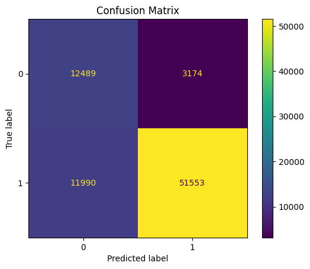

```
Classification Report:
              precision    recall  f1-score   support

           0       0.51      0.80      0.62     15663
           1       0.94      0.81      0.87     63543

    accuracy                           0.81     79206
   macro avg       0.73      0.80      0.75     79206
weighted avg       0.86      0.81      0.82     79206
```

```python
# Calling the function model_performance()
print("Class weight Model Performance:")
print("-" * 33)
model_performance(class_weights_model, X_train_scaled, Y_train, X_val_scaled, Y_val)
```

### Class Weight Model Performance - Insights :

- Precision is high at 0.94, with recall at 0.81.
- F1 score (0.87) shows a good balance, slightly favoring precision.
- Accuracy drops to 0.81, reflecting a shift in handling class imbalance.

### Business Implication

- Similar to the customized threshold in the base model, high precision reduces the number of false positives, beneficial for efficient resource allocation.
- The relatively lower recall still risks missing some defaulters, requiring a careful analysis of the cost implications.

### 09.6 ROC AUC Curve for Class Weight Model

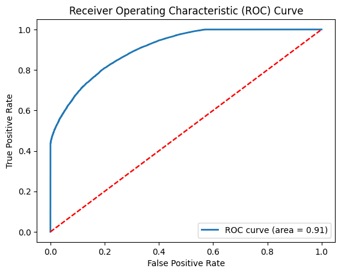

```python
#Hyperparameter tuning of Threshold
from sklearn.metrics import roc_curve, roc_auc_score
# Predict the probabilities for the positive class
Y_pred_prob_val = class_weights_model.predict_proba(X_val_scaled)[:, 1]
# Compute ROC curve and ROC area
fpr, tpr, thresholds = roc_curve(Y_val, Y_pred_prob_val)
roc_auc = roc_auc_score(Y_val, Y_pred_prob_val)
# Plot ROC curve
plt.figure()
plt.plot(fpr, tpr, lw=2, label='ROC curve (area = %0.2f)' % roc_auc)
plt.plot([0,1], [0,1], 'r--')
plt.plot(fpr,fpr,'--',color='red')
plt.xlabel('False Positive Rate')
plt.ylabel('True Positive Rate')
plt.title('Receiver Operating Characteristic (ROC) Curve')
plt.legend(loc="lower right")
plt.show()
```

### From the business domain we should ask about the acceptable FPR.

- Lets us consider FPR should be less than 0.2

```python
# Find the Optimal threshold
x = 0.2
fpr < x # Get the input from the business domain
# Find the correct threshold when fpr < 0.2 and maximum tpr
Optimal_threshold = thresholds[np.argmax(tpr[fpr < 0.2])]
max_tpr = tpr[np.argmax(tpr[fpr < 0.2])]
roc_auc = roc_auc_score(Y_val, Y_pred_prob_val)
# Print the result
print(f"For FPR < {x},")
print(f"Maximum TPR is: {(max_tpr).round(2)}")
print(f"Optimal Threshold is: {(Optimal_threshold).round(2)}")
print(f"AU-ROC Score: {(roc_auc).round(2)}")
```

```
For FPR < 0.2,
Maximum TPR is: 0.81
Optimal Threshold is: 0.5
AU-ROC Score: 0.91
```

```
Class weight Model Performance after customizing the threshold:
-----------------------------------------------------------------
Test Accuracy: 0.81
Test Precision: 0.94
Test Recall: 0.81
Test F1 Score: 0.87

Confusion Matrix:
[[12532  3131]
 [12129 51414]]
```

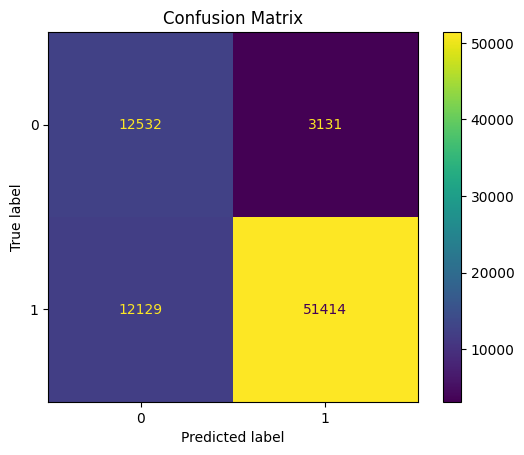

```python
# Model Performance after custamizing the threshold:
Y_pred_custom_threshold = (Y_pred_prob_val >= Optimal_threshold).astype(int)
print("Class weight Model Performance after customizing the threshold:")
print("-" * 65)
print(f"Test Accuracy: {round(accuracy_score(Y_val, Y_pred_custom_threshold),2)}")
print(f"Test Precision: {round(precision_score(Y_val, Y_pred_custom_threshold),2)}")
print(f"Test Recall: {round(recall_score(Y_val, Y_pred_custom_threshold),2)}")
print(f"Test F1 Score: {round(f1_score(Y_val, Y_pred_custom_threshold),2)}")
# Confusion Matrix
print("\nConfusion Matrix:")
cm = confusion_matrix(Y_val, Y_pred_custom_threshold)
print(cm)
ConfusionMatrixDisplay(cm).plot()
plt.title('Confusion Matrix')
plt.show()
```

### Class Weight Model Performance - After Tuning - Insights

- Precision remains high at 0.94, with a recall of 0.81.
- The F1 score is consistent at 0.87, similar to the non-threshold-adjusted class weight model.
- Accuracy remains at 0.81.

### Business Implication

- Consistent precision with a slight drop in recall suggests the threshold adjustment had minimal impact on the model's trade-off balance.
- The business may still face risks related to missed defaulters due to the recall rate.

### 09.7 Handling Imbalance Data - SMOTE

- SMOTE(Synthetically Minority Oversampling Technique) helps in balancing the class distribution by generating synthetic instances of the minority class, which can improve the performance of classification algorithms.
- By creating synthetic samples, SMOTE can help algorithms learn more generalized decision boundaries, reducing the bias towards the majority class

```python
from imblearn.over_sampling import SMOTE
# Create an instance of SMOTE
smt = SMOTE()
# Check the value counts before SMOTE
print('Before SMOTE')
print(Y_train.value_counts())
print()
# Perform SMOTE on the training data
# Oversample the training data using SMOTE
X_sm, Y_sm = smt.fit_resample(X_train_scaled, Y_train)
print('After Oversampling')
print(Y_sm.value_counts())
print()
```

```
Before SMOTE
loan_status
1    191103
0     46515
Name: count, dtype: int64

After Oversampling
loan_status
1    191103
0    191103
Name: count, dtype: int64
```

```python
# Initialize the Logistic Regression model
SMOTE_model = LogisticRegression(random_state=1)
# Fit the model on the training data
SMOTE_model.fit(X_sm, Y_sm)
```

```
LogisticRegression(random_state=1)
```

```
SMOTE Model Performance:
-------------------------
Training Accuracy: 0.81
Training Precision: 0.81
Training Recall: 0.81
Training F1 Score: 0.81

Test Accuracy: 0.81
Test Precision: 0.94
Test Recall: 0.81
Test F1 Score: 0.87

Confusion Matrix:
[[12502  3161]
 [12176 51367]]
```

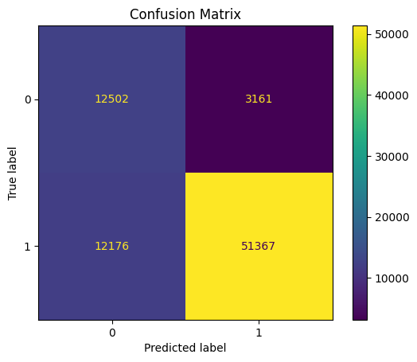

```
Classification Report:
              precision    recall  f1-score   support

           0       0.51      0.80      0.62     15663
           1       0.94      0.81      0.87     63543

    accuracy                           0.81     79206
   macro avg       0.72      0.80      0.74     79206
weighted avg       0.86      0.81      0.82     79206
```

```python
# Calling the function model_performance()
print("SMOTE Model Performance:")
print("-" * 25)
model_performance(SMOTE_model, X_sm, Y_sm, X_val_scaled, Y_val)
```

### Business Implication

- Balanced precision and recall mean the model handles class imbalance well, but with moderate precision, there's a risk of false positives.
- The moderate recall suggests some defaulters might still be missed, although it might be more balanced than other approaches

### 09.8 ROC AUC Curve for SMOTE Model

- The ROC AUC curve (Receiver Operating Characteristic - Area Under the Curve) is a performance measurement for classification problems at various threshold settings.
- It's particularly useful for evaluating the performance of a binary classifier

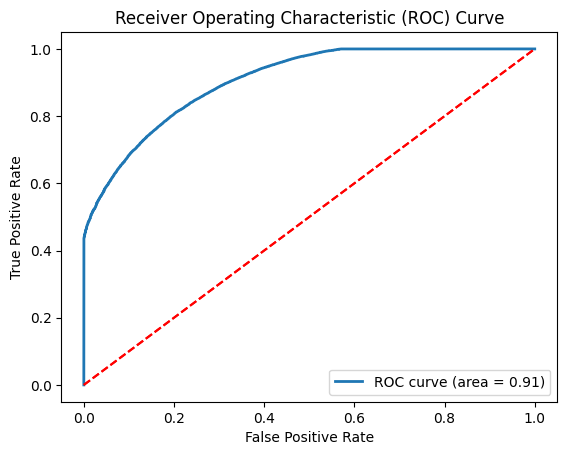

```python
# Hyperparameter tuning of Threshold
from sklearn.metrics import roc_curve, roc_auc_score
# Predict the probabilities for the positive class
Y_pred_prob_val = SMOTE_model.predict_proba(X_val_scaled)[:, 1]
# Compute ROC curve and ROC area
fpr, tpr, thresholds = roc_curve(Y_val, Y_pred_prob_val)
roc_auc = roc_auc_score(Y_val, Y_pred_prob_val)
# Plot ROC curve
plt.figure()
plt.plot(fpr, tpr, lw=2, label='ROC curve (area = %0.2f)' % roc_auc)
plt.plot([0,1], [0,1], 'r--')
plt.plot(fpr,fpr,'--',color='red')
plt.xlabel('False Positive Rate')
plt.ylabel('True Positive Rate')
plt.title('Receiver Operating Characteristic (ROC) Curve')
plt.legend(loc="lower right")
plt.show()
```

### From the business domain we should ask about the acceptable FPR.

- Lets us consider FPR should be less than 0.2

```python
# Find the Optimal threshold
x = 0.2
fpr < x # Get the input from the business domain
# Find the correct threshold when fpr < 0.2 and maximum tpr
Optimal_threshold = thresholds[np.argmax(tpr[fpr < 0.2])]
max_tpr = tpr[np.argmax(tpr[fpr < 0.2])]
roc_auc = roc_auc_score(Y_val, Y_pred_prob_val)
# Print the result
print(f"For FPR < {x},")
print(f"Maximum TPR is: {(max_tpr).round(2)}")
print(f"Optimal Threshold is: {(Optimal_threshold).round(2)}")
print(f"AU-ROC Score: {(roc_auc).round(2)}")
```

```
For FPR < 0.2,
Maximum TPR is: 0.81
Optimal Threshold is: 0.5
AU-ROC Score: 0.91
```

```
SMOTE Model Performance after customizing the threshold:
----------------------------------------------------------
Test Accuracy: 0.8
Test Precision: 0.94
Test Recall: 0.81
Test F1 Score: 0.87

Confusion Matrix:
[[12531  3132]
 [12322 51221]]
```

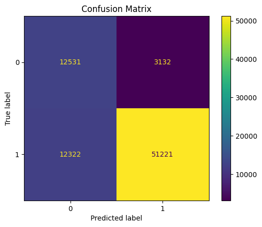

```python
# Model Performance after custamizing the threshold:
Y_pred_custom_threshold = (y_pred_prob_val >= Optimal_threshold).astype(int)
print("SMOTE Model Performance after customizing the threshold:")
print("-" * 58)
print(f"Test Accuracy: {round(accuracy_score(Y_val, Y_pred_custom_threshold),2)}")
print(f"Test Precision: {round(precision_score(Y_val, Y_pred_custom_threshold),2)}")
print(f"Test Recall: {round(recall_score(Y_val, Y_pred_custom_threshold),2)}")
print(f"Test F1 Score: {round(f1_score(Y_val, Y_pred_custom_threshold),2)}")
# Confusion Matrix
print("\nConfusion Matrix:")
cm = confusion_matrix(Y_val, Y_pred_custom_threshold)
print(cm)
ConfusionMatrixDisplay(cm).plot()
plt.title('Confusion Matrix')
plt.show()
```

### Business Implication

- The higher precision reduces false positives, aligning with the business need to minimize unnecessary actions on non-defaulting borrowers
- However, the drop in recall may lead to some missed defaulters, presenting a risk that needs to be managed

### 09.9 Conclusion : Best Model Selection

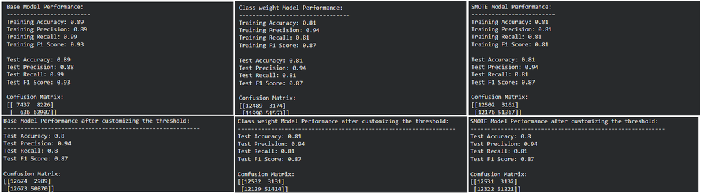

### 09.10 Final Check with X_test Data

```python
#Predict the probabilities
Y_pred_prob_test = class_weights_model.predict_proba(X_test_scaled)[:, 1]
```

```
Final Model Performance with customized threshold(0.51) of test data
----------------------------------------------------------------------
Test Accuracy: 0.8
Test Precision: 0.95
Test Recall: 0.8
Test F1 Score: 0.86

Confusion Matrix:
[[12580  2915]
 [12940 50771]]
```

```
<sklearn.metrics._plot.confusion_matrix.ConfusionMatrixDisplay at 0x7d86cace20f0>
```

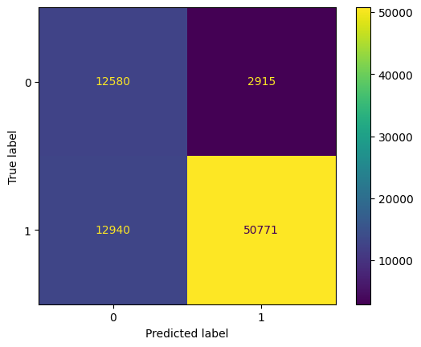

```python
# Final Test Performance after using the custamized threshold:
Optimal_threshold = 0.51
Y_pred_custom_threshold = (Y_pred_prob_test >= Optimal_threshold).astype(int)
print(f"Final Model Performance with customized threshold({Optimal_threshold}) of test data")
print("-" * 70)
print(f"Test Accuracy: {round(accuracy_score(Y_test, Y_pred_custom_threshold),2)}")
print(f"Test Precision: {round(precision_score(Y_test, Y_pred_custom_threshold),2)}")
print(f"Test Recall: {round(recall_score(Y_test, Y_pred_custom_threshold),2)}")
print(f"Test F1 Score: {round(f1_score(Y_test, Y_pred_custom_threshold),2)}")
# Confusion Matrix
print("\nConfusion Matrix:")
cm = confusion_matrix(Y_test, Y_pred_custom_threshold)
print(cm)
ConfusionMatrixDisplay(cm).plot()
```

### 09.10.1 Feature Importance

```python
#Extracting columns and Coefficients
feature_names = X_train.columns
importances = class_weights_model.coef_[0]
```

```python
#Create a DataFrame for feature importance
feature_importance_df = pd.DataFrame({'Feature': feature_names, 'Importance': importances})
```

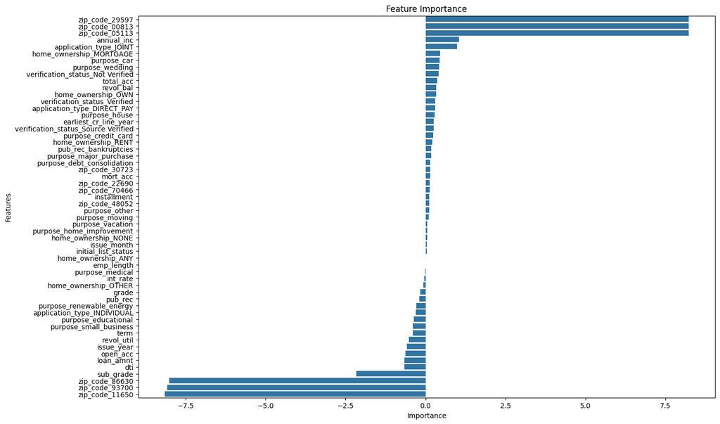

```python
#Plot the feature importances
plt.figure(figsize=(15, 10))
# Sort the DataFrame by Importance in descending order
sorted_features = feature_importance_df.sort_values(by='Importance', ascending=False)
sns.barplot(y=sorted_features['Feature'], x=sorted_features['Importance'])
plt.ylabel('Features')
plt.xlabel('Importance')
plt.title('Feature Importance')
plt.show()
```

### 10. Questions

### 10.1 What percentage of customers have fully paid their Loan Amount?

```python
round(df['loan_status'].value_counts(normalize = True),4)*100
```

| loan_status | proportion |
| --- | --- |
| Fully Paid | 80.39 |
| Charged Off | 19.61 |

**dtype:** float64

- Ans : 80.39% of customers have fully paid their loan amount.

### 10.2 Comment about the correlation between Loan Amount and Installment features.

```python
(correlation['loan_amnt']['installment']).round(2)
```

```
np.float64(0.95)
```

- Ans : The high correlation coefficient of 0.95 between loan_amnt and installment suggests a strong positive linear relationship between these two variables. This indicates that as the loan amount increases, the installment amount also increases proportionally

### 10.3 The majority of people have home ownership as #MORTGAGE

```python
df['home_ownership'].value_counts()
```

| home_ownership | count |
| --- | --- |
| MORTGAGE | 198348 |
| RENT | 159790 |
| OWN | 37746 |
| OTHER | 112 |
| NONE | 31 |
| ANY | 3 |

**dtype:** int64

- Ans : Mortgage

### 10.4 People with grades ‘A’ are more likely to fully pay their loan. (T/F)

```python
pd.crosstab(df['loan_status'],df['grade'],normalize = 'index', margins = True).round(4)
```

| grade loan_status | A | B | C | D | E | F | G |
| --- | --- | --- | --- | --- | --- | --- | --- |
| Charged Off | 0.0520 | 0.1878 | 0.2890 | 0.2361 | 0.1515 | 0.0648 | 0.0188 |
| Fully Paid | 0.1889 | 0.3186 | 0.2624 | 0.1419 | 0.0620 | 0.0212 | 0.0050 |
| All | 0.1621 | 0.2930 | 0.2676 | 0.1604 | 0.0795 | 0.0297 | 0.0077 |

- Ans : People with grades ‘A’ are more likely to fully pay their loan - True

### 10.5 Name the top 2 afforded job titles

```python
((df[['loan_status','emp_title']].value_counts(normalize=True))*100).round(2)
```

| loan_status | emp_title | proportion |
| --- | --- | --- |
| Fully Paid | Teacher | 5.18 |
| Charged Off | Teacher | 1.72 |
| Fully Paid | Manager | 0.84 |
|  | Registered Nurse | 0.37 |
|  | RN | 0.37 |
| ... | ... | ... |
| Charged Off | Area super visor | 0.00 |
|  | Area Sales Manager | 0.00 |
|  | ADM | 0.00 |
|  | 2706 Housekeeper/Food Service Cleaner | 0.00 |
|  | Director | 0.00 |

185292 rows × 1 columns

**dtype:** float64

### 10.6 Thinking from a bank's perspective, which metric should our primary focus be on..

- ROC AUC
- Precision
- Recall
- F1 Score
- Ans : Choosing the right metric depends on the business priorities. Precision should be the primary focus from a risk management perspective. Ensuring high precision helps the bank avoid approving risky loans and potential financial losses. However, an optimal balance using metrics like the F1 Score could also be considered to capture both aspects effectively.

### 10.7 How does the gap in precision and recall affect the bank?

- Ans:
  - High Precision and Low Recall: The bank approves fewer loans, but those approved are more likely to be fully repaid. However, many potentially creditworthy borrowers might be missed, resulting in lost opportunities and reduced revenue
  - High Recall and Low Precision: The bank approves more loans, capturing most potential defaulters. This increases the risk of loan defaults, leading to higher financial losses and potentially impacting profitability

### 10.8 Which were the features that heavily affected the outcome?

```python
feature_importance_df['Abs_Importance'] = abs(feature_importance_df['Importance'])
feature_importance_df.sort_values(by='Abs_Importance', ascending=False).head(10)
```

|  | Feature | Importance | Abs_Importance |
| --- | --- | --- | --- |
| 50 | zip_code_29597 | 8.236622 | 8.236622 |
| 46 | zip_code_00813 | 8.233324 | 8.233324 |
| 47 | zip_code_05113 | 8.231142 | 8.231142 |
| 48 | zip_code_11650 | -8.158273 | 8.158273 |
| 55 | zip_code_93700 | -8.069762 | 8.069762 |
| 54 | zip_code_86630 | -8.014710 | 8.014710 |
| 5 | sub_grade | -2.162148 | 2.162148 |
| 7 | annual_inc | 1.043405 | 1.043405 |
| 45 | application_type_JOINT | 0.978442 | 0.978442 |
| 8 | dti | -0.655829 | 0.655829 |

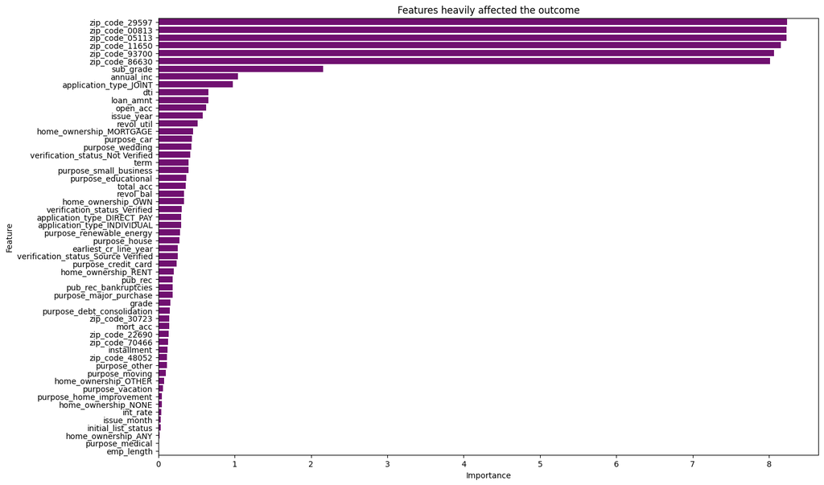

```python
plt.figure(figsize=(15, 10))
Abs_Importance_df = feature_importance_df.sort_values(by='Abs_Importance', ascending=False)
sns.barplot(y = Abs_Importance_df['Feature'], x = Abs_Importance_df['Abs_Importance'],color = 'purple')
plt.xlabel('Importance')
plt.title('Features heavily affected the outcome')
plt.show()
```

### 10.9 Will the results be affected by geographical location? (Yes/No)

- Ans : Yes, The results are affected by geographical location, as indicated by the feature importance scores for zip_code variables. The high importance scores of zip_code variables suggest that geographical location plays a significant role in predicting loan default. This could be due to regional economic conditions, local credit behaviors, or different living costs, which can influence a borrower's ability to repay loans.

## 11. Business Insights & Recommendation

### 02. Loan Term Preferences:

- Insight: The majority of loans are for 36 months, and this term is associated with higher proportions of both fully paid and charged-off loans. Loans with a term of 60 months are less common.
- Recommendation: Continue offering 36-month loan terms as they align well with both borrower preferences and repayment patterns. Analyze if shorter or longer terms could be adjusted based on specific borrower profiles to balance risk and profitability.

### 03. Credit Grades:

- Insight: Higher grades (A and B) are associated with higher repayment rates, while lower grades (C and below) are more prone to defaults.
- Recommendation: Use credit grades as a primary factor in underwriting decisions. Offer more favorable terms to borrowers with higher credit grades and consider stricter criteria or higher interest rates for lower grades.

### 04. Home Ownership Status:

- Insight: Borrowers who own homes or have mortgages tend to have higher repayment rates compared to renters.
- Recommendation: Consider home ownership status as an important factor in assessing creditworthiness. Potentially provide more favorable terms to homeowners, as they show a higher likelihood of fully repaying loans.

### 05. Geographical Impact:

- Insight: Features related to zip codes show significant importance in the model, indicating that geographical location impacts loan repayment behavior. Economic conditions and cost of living can vary greatly by location.
- Recommendation: Integrate geographical data into credit assessments to better predict repayment abilities. Tailor loan products and terms based on regional economic conditions to mitigate risks associated with geographical variability

## Conclusion

- Model Selection: The final model with a customized threshold shows strong precision (0.95) and a robust F1 score (0.86). It balances minimizing false positives and maintaining a reasonable recall rate, making it suitable for deployment.
- Action: Regularly monitor and update the model to adapt to changes in borrower behavior and market conditions. Use the insights to refine credit policies and improve loan performance metrics.